# Biologie et données : une nouvelle lecture de la biodiversité

Projet Génome Québec – ADN environnemental

Claudia D. TCHOBO, Jospine D. ABADASSI, Myrix MASSAMBA, Aïda T. SIGUE, Mireille MEGNIDIO

2026-11-25

**Programme de formation en Science des Données au Féminin en Afrique Francophone**

**RAPPORT DE FIN DE FORMATION**

**Diplôme : Certification en Science des données**

**Groupe n° : 4**

**Comité d’organisation :** Pr. Thierry WARIN, Dr. Bernice BANCOLE, Dr Josette-René LANDRY

**Période de formation : Mars 2023 - Novembre 2026**

# 1 Thème du projet

Analyse de la biodiversité aquatique par ADN environnemental : caractérisation des poissons et des invertébrés au Québec.

# 2 Introduction

Les données soumises à notre réflexion proviennent d’une initiative de **science citoyenne de Génome Québec, nommée Mission ADN-eau**. Des élèves d’écoles secondaires et de collèges du sud du Québec ont récolté des échantillons d’eau dans des cours d’eau proches de leur établissement. L’**ADN environnemental (ADNe)** contenu dans ces échantillons a ensuite été séquencé afin d’identifier les espèces présentes et d’approfondir nos connaissances sur la biodiversité. La Mission ADN-eau s’inscrit dans une démarche plus large de Génome Québec.

L’ADNe est, selon la formule de Génome Québec, *« une empreinte génétique laissée par les organismes vivants dans leur environnement »* : mucus, cellules de peau, excréments, gamètes. Un simple litre d’eau filtré permet ainsi de détecter des poissons ou des invertébrés sans les capturer, ce qui rend la méthode **peu invasive, peu coûteuse sur le terrain et accessible au grand public**.

L’ADN environnemental (ADNe) permet de détecter, à partir de traces génétiques présentes dans l’environnement, des organismes ayant fréquenté un milieu. Cette approche constitue un outil complémentaire aux méthodes classiques d’inventaire de la biodiversité aquatique. Son interprétation nécessite toutefois une attention particulière à la qualité des données, à la résolution des assignations taxonomiques et aux signaux pouvant provenir des contrôles négatifs.

Le présent rapport porte sur des données d’ADNe ciblant les poissons et les invertébrés dans différents sites d’échantillonnage au Québec. Il vise à décrire les données obtenues, à examiner la diversité taxonomique détectée et à identifier les signaux qui nécessitent une vérification avant toute interprétation écologique définitive.

# 3 Objectifs général et spécifiques

## 3.1 Objectif général

Ce projet a pour but d’analyser les données d’ADNe des poissons et des invertébrés afin d’évaluer leur qualité, de caractériser les détections taxonomiques et d’examiner les signaux atypiques observés dans les échantillons et les contrôles.

## 3.2 Objectifs spécifiques

Plus spécifiquement, il s’agit :

- **i**. **OS1 :** assurer la qualité et la fiabilité des données d’ADNe utilisées pour caractériser la biodiversité des poissons et des invertébrés.
- **ii**. **OS2 :** caractériser la diversité taxonomique des poissons et des invertébrés et décrire sa répartition dans les sites d’échantillonnage.
- **iii**. **OS3 :** évaluer les signaux potentiels de contamination et les détections taxonomiques atypiques afin d’identifier les OTU nécessitant des vérifications complémentaires.

# 4 Matériels et méthodes

## 4.1 Milieu d’étude

L’étude s’est effectuée au Québec.

## 4.2 Collecte des données

### 4.2.1 Description des données

Les données reçues concernent quatre fichiers portant sur **des espèces de Poissons (Fish)** et **des espèces d’Invertébrés (Invertebrates)** à raison de deux fichiers par type d’être vivant. L’un des fichiers a fait référence à la localisation des sites d’échantillonnage d’eau récoltée et un autre concerne les OTU ou taxonomie identifiée.

**OTU** désigne une *unité taxonomique opérationnelle*. Lors de l’analyse d’amplicons métagénomiques, il est courant de réunir les amplicons présentant une homologie de séquence supérieure à 99% sous un même groupe afin de palier aux erreurs de séquençage. Dès lors ce groupe correspond à un organisme et la séquence la plus fréquemment trouvée dans le groupe est celle qui ne comporte pas d’erreur de séquençage. **Ce groupe d’amplicon et leur séquence représentative constituent un OTU**. Par la suite, des analyses ont été effectuées pour identifier ou décrire chacun des OTUs. Dans certains cas, il est possible d’avoir une identification au niveau d’une espèce ou d’une souche précise. Dans d’autre cas, la séquence n’est pas suffisamment unique pour permettre une identification précise. La dernière colonne des tables partagées contient une identification putative des OTUs. Notons que terme **amplicon** est utilisé pour décrire la séquence de la région de l’ADN ribosomal qui est ciblée par l’amplification PCR. Ce sont ces régions qui ont été séquencées et c’est à partir de leur séquence que nous avons inféré l’identité des espèces trouvées. Pour revenir aux différents fichiers qui se ressemblent et donc contiennent les mêmes colonnes, prenons en exemple le fichier Poissons.tsv, chaque ligne représente un OTU et chaque colonne représente un site d’échantillonnage. Afin de générer ce fichier, un séquençage d’amplicons a été effectué pour chacun des sites. Les amplicons détectés sur l’ensemble des sites ont ensuite été combinés en OTUs. Le tableau rapporte le nombre d’amplicons trouvés pour chacun des OTUs à chacun des sites. Compte-tenu de la diversité des sites, il est possible qu’une espèce observée dans un site soit complètement absente dans les autres.

### 4.2.2 Organisation de l’analyse

L’analyse repose sur quatre fichiers : les **matrices d’OTU des poissons et des invertébrés** ainsi que les fichiers de métadonnées (mapping) associés. Les matrices contiennent les identifiants des OTU, les comptages de lectures par échantillon et les annotations taxonomiques. Les mappings fournissent notamment les informations sur les échantillons, leur type et leur localisation.

### 4.2.3 Précautions d’interprétation

- Une **OTU** est une unité moléculaire définie à partir des séquences; elle ne correspond pas automatiquement à une espèce confirmée.
- Le nombre de lectures reflète un signal de séquençage et ne constitue pas une mesure directe de l’abondance des organismes.
- Les poissons et les invertébrés étant étudiés avec des marqueurs/essais distincts, leurs nombres absolus de lectures et leurs indices de diversité ne doivent pas être comparés comme s’ils étaient directement équivalents.
- Lorsque les sites ne comportent qu’un seul échantillon, les comparaisons spatiales restent descriptives.
- La présence d’une OTU dans un blanc constitue un signal à examiner, mais ne prouve pas à elle seule une contamination. De même, l’absence dans les blancs ne confirme pas automatiquement l’exactitude de son annotation taxonomique.

## 4.3 Traitement et analyse des données

Les traitements sont réalisés dans R. Les analyses distinguent les échantillons biologiques, les blancs de terrain et les blancs d’extraction. Les coordonnées GPS sont utilisées lorsqu’elles sont disponibles pour représenter les sites. Comme expliqué plus haut, nous avons deux espèces et quatre fichiers : un fichier de localisation et un fichier qui renseigne les OTUs. Les descriptions des échantillons sont disponibles dans les fichiers “mapping” de l’expérience. Ils contiennent les IDs des échantillons, le nom de l’école, des cours d’eau et du site d’échantillonnage. Il est également indiqué s’il s’agit d’échantillons biologiques ou de blancs de terrain. Le blanc d’extraction s’appelle “Blanc.Extraction”.

Le fichier contenant les espèces se présente comme suit : ● La colonne **#FEATURE_ID** contient un ID arbitraire pour chacun des OTUs générés. Chaque OTU a sa propre ligne dans la table. ● La colonne **taxonomy** contient l’assignation taxonomique des OTUS. Les informations sont indiquées de façon hiérarchique : · **k__ : kingdom** · **p__ : phylum** · **c__ : class** · **o__ : order** · **f__ : family** · **g__ : genus** · **s__ : species** ● Les autres colonnes portent les ID des échantillons comme dans les fichiers mapping par exemple : **MI.M05812_0023.001.FLD0193.1-1-G-a_MiFish**

**MI = Run Miseq** **M05812 = ID du séquenceur** **0023 = numéro de la run** **001 = lane du séquenceur** **FLD0193 = index de multiplexage de l’échantillon** **1-1-G-a_MiFish = nom de l’échantillon**

Sur la base de ces fichiers, il a été constaté que pour une espèce, les fichiers ont une donnée commune : l’ID des échantillons.

Cependant, dans l’un des fichiers, ces ID se présentent sous forme de colonne et dans l’autre sous forme de ligne.

**a) Transformer l’un des fichiers du format large à un format long** Etant donné que les ID d’échantillonage sont dans les deux fichiers, il devenait nécessaire de joindre ces fichiers et pour ce faire, il fallait transformer l’un des fichiers. Le fichier dans lequel les ID sont sur des colonnes a été transformé en utilisant la fonction pivot_longer. En R, `pivot_longer` est une fonction du package `tidyr` utilisée pour transformer des données d’un format large à un format long. Ce type d’opération est courant lorsqu’on travaille avec des ensembles de données où les variables sont stockées en tant que colonnes et que l’on souhaite transformer ces colonnes en lignes.

La fonction `pivot_longer` prend plusieurs arguments, y compris le nom des données à transformer, les noms des colonnes à transformer en lignes, et éventuellement, les noms des nouvelles colonnes à créer pour stocker les valeurs des variables et les étiquettes pour ces nouvelles variables.

**b) Joindre les deux fichiers** La fonction `full_join()` est une fonction du package `dplyr` en R, qui permet de joindre deux dataframes en utilisant une opération de jointure (join). Une jointure (join) combine les lignes de deux dataframes en fonction d’une ou plusieurs colonnes communes. Dans le contexte présent, il s’agit d’une colonne, l’ID des échantillons. Ce dataframe a été enregistré dans un fichier. Nous nous retrouvons donc avec un fichier pour chaque espèce.

**c) Nettoyage des données** Après l’étape de jointure, la colonne représentant les OTUs ou taxonomy a été analysé et il a été remarqué que certains OTUs ne portaient pas tous les éléments : **k__**,** p**,** c, o**,** f, g__** et **s__** (il est déjà question de Poissons et Invertébrés dans notre étude). Soit pour ces colonnes, il y a eu une erreur de saisie soit pour ces colonnes les différents éléments constituant une espèce n’ont pas été identifiés. Quoi qu’il en soit ces lignes ont été placés dans un autre fichier et supprimer des fichiers sur lesquels le travail a été fait.

**d) Création des colonnes k, p, c, o, f et g** Ces colonnes ont été crées pour identifier sur chaque OTU les éléments qui le constituent.

De toutes ces analyses, nous obtenons le dictionnaire des variables suivant :

**Variables** **Définition** **Type** **FEATURE_ID** : ID arbitraire pour chacun des OTUs générés ; Numérique **taxonomy** : Assignation taxonomique des OTUs sous forme de k__Eukaryota;p__Ochrophyta;c__Xanthophyceae;o__Mischococcales;f__Pleurochloridaceae;g__Monodus ; Chaîne de caractère **SampleID** : ID echantillon sous la forme de MI.M05812_0023.001.FLD0193.1-1-G-a_MiFish ; Chaîne de caractère **value** Nombre d’amplicons appartenant à un OTU Numérique **alias** : Nom de l’échantillon : pour MI.M05812_0023.001.FLD0193.1-1-G-a_MiFish, l’alias est 1-1-G-a ; Chaîne de caractère **siteEchantillon**: Site d’échantillon ; Chaîne de caractère **Longitude** : Longitude du site ; Numérique **Latitude** : Latitude du site ; Numérique **TypeEchantillon** : Type de l’échantillon ; Chaîne de caractère **color**: Des couleurs ont été attribuées à chaque type d’échantillon ; 1 : Biologique ; 2 : Blanc ; 3 : Blanc d’extraction Numérique **Treatment** : Site de traitement de l’ADN ribosomal; Chaîne de caractère **k** : kingdom ; Chaîne de caractère **p** : phylum ; Chaîne de caractère **c** : class ; Chaîne de caractère **o** : order ; Chaîne de caractère **f** : family ; Chaîne de caractère **g** : genus ; Chaîne de caractère

## 4.4 Préparation et importation des données

### 4.4.1 Chargement des packages

Les bibliothèques R ont été chargées afin de disposer des fonctions nécessaires à l’importation, au traitement, aux analyses statistiques et à la visualisation des données d’ADNe.

```r
## 1. Chargement des packages
library(tidyverse)
library(vegan)
library(knitr)
library(kableExtra)
library(leaflet)
library(gsheet)
library(googlesheets4)
library(leaflet.extras)
library (leafem)
library(tidyr)
library(stringr)
library(purrr)
library(readr)
```

```r
googlesheets4::gs4_auth()
```

```
## ! Using an auto-discovered, cached token.
```

```
##   To suppress this message, modify your code or options to clearly consent to
##   the use of a cached token.
```

```
##   See gargle's "Non-interactive auth" vignette for more details:
```

```
## ℹ The googlesheets4 package is using a cached token for
##   'claudytchob@gmail.com'.
```

### 4.4.2 Importation des fichiers Google Sheets

Les matrices d’OTU et les métadonnées des poissons et des invertébrés ont été importées. Ces données ont constitué la base des analyses de qualité, de diversité taxonomique et des signaux atypiques.

```r
## 2. Importation des quatre fichiers Google Sheets

# 1. Mapping des invertébrés
mapping_invertebres <- gsheet2tbl(
  "https://docs.google.com/spreadsheets/d/1guPot-d5chEHyjYUn_Ufx51YMRfCkJGOOFLAnS1luhE/edit?gid=0#gid=0"
)

# 2. Mapping des poissons
mapping_poissons <- gsheet2tbl(
  "https://docs.google.com/spreadsheets/d/1xRhjszPQpBNGDPy_O8rTBwMlMt8tBXHgsoCMpl_bFJQ/edit?gid=1480193508#gid=1480193508"
)

# 3. Données GPS des poissons
data_poissons <- gsheet2tbl(
  "https://docs.google.com/spreadsheets/d/1oxun-u-54L16oryxi7Kjcsuzc890y39LY7qVKSaQGaY/edit?gid=1475903627#gid=1475903627"
)

# 4. Données GPS des invertébrés
data_invertebres <- gsheet2tbl(
  "https://docs.google.com/spreadsheets/d/1Kv4m4jZvFULynTM57XYCKt-fN7MOSBf-r9PqhDLrKSI/edit?gid=211150138#gid=211150138"
)
```

# 5 Résultats de l’analyse des données

## 5.1 OS1 : Assurer la qualité et la fiabilité des données d’ADNe utilisées pour caractériser la biodiversité des poissons et des invertébrés

### 5.1.1 Dimensions et noms des colonnes

L’exploration des données a révélé **7 727 OTU chez les invertébrés** et **310 chez les poissons**. Les deux fichiers de métadonnées ont chacun présenté **55 enregistrements**. Ces différences ont reflété la structure des données et n’ont pas permis de conclure à une différence directe de biodiversité entre les groupes.

```r
## 3. Dimensions et noms des colonnes

donnees <- list(
  mapping_invertebres = mapping_invertebres,
  mapping_poissons = mapping_poissons,
  data_poissons = data_poissons,
  data_invertebres = data_invertebres
)

for (nom in names(donnees)) {

  cat("\n====================================\n")
  cat("FICHIER :", nom, "\n")
  cat("====================================\n")

  cat("Nombre de lignes :", nrow(donnees[[nom]]), "\n")
  cat("Nombre de colonnes :", ncol(donnees[[nom]]), "\n")

  cat("\nNoms des colonnes :\n")
  print(names(donnees[[nom]]))

  cat("\nStructure des données :\n")
  str(donnees[[nom]])
}
```

```
##
## ====================================
## FICHIER : mapping_invertebres
## ====================================
## Nombre de lignes : 55
## Nombre de colonnes : 12
##
## Noms des colonnes :
##  [1] "#SampleID"           "alias"               "CoursEau"
##  [4] "SiteEchantillonnage" "Longitude(X)"        "Latitude(Y)"
##  [7] "TypeEchantillon"     "Couleur"             "Treatment"
## [10] "SampleID"            "Color_fish_invert"   "Color_Invert"
##
## Structure des données :
## spc_tbl_ [55 × 12] (S3: spec_tbl_df/tbl_df/tbl/data.frame)
##  $ #SampleID          : chr [1:55] "MI.M05812_0023.001.FLD0097.1-1-G-a" "MI.M05812_0023.001.FLD0098.2-1-H-a" "MI.M05812_0023.001.FLD0099.2-2-H-b" "MI.M05812_0023.001.FLD0100.2-3-H-c" ...
##  $ alias              : chr [1:55] "1.1.G.a" "2.1.H.a" "2.2.H.b" "2.3.H.c" ...
##  $ CoursEau           : chr [1:55] "Riviere.Richelieu" "Bassin.de.Chambly" "Bassin.de.Chambly" "Bassin.de.Chambly" ...
##  $ SiteEchantillonnage: chr [1:55] "Montee.Robert" "Les.ecluses" "Fort.de.Chambly" "Le.Parc.Martel" ...
##  $ Longitude(X)       : num [1:55] -73.3 -73.3 -73.3 -73.3 -73.6 ...
##  $ Latitude(Y)        : num [1:55] 45.5 45.4 45.4 45.4 45.5 ...
##  $ TypeEchantillon    : chr [1:55] "Biologique" "Biologique" "Biologique" "Biologique" ...
##  $ Couleur            : num [1:55] 1 1 1 1 1 1 1 1 1 1 ...
##  $ Treatment          : chr [1:55] "Ecole.Secondaire.Andre-Laurendeau_Riviere.Richelieu_Montee.Robert_Biologique" "Ecole.secondaire.de.Chambly_Bassin.de.Chambly_Les.ecluses_Biologique" "Ecole.secondaire.de.Chambly_Bassin.de.Chambly_Fort.de.Chambly_Biologique" "Ecole.secondaire.de.Chambly_Bassin.d…
##  $ SampleID           : chr [1:55] "MI.M05812_0023.001.FLD0097.1-1-G-a" "MI.M05812_0023.001.FLD0098.2-1-H-a" "MI.M05812_0023.001.FLD0099.2-2-H-b" "MI.M05812_0023.001.FLD0100.2-3-H-c" ...
##  $ Color_fish_invert  : num [1:55] 4 4 4 4 4 4 4 4 4 4 ...
##  $ Color_Invert       : chr [1:55] "Rouge" "Rouge" "Rouge" "Rouge" ...
##  - attr(*, "spec")=
##   .. cols(
##   ..   `#SampleID` = col_character(),
##   ..   alias = col_character(),
##   ..   CoursEau = col_character(),
##   ..   SiteEchantillonnage = col_character(),
##   ..   `Longitude(X)` = col_double(),
##   ..   `Latitude(Y)` = col_double(),
##   ..   TypeEchantillon = col_character(),
##   ..   Couleur = col_double(),
##   ..   Treatment = col_character(),
##   ..   SampleID = col_character(),
##   ..   Color_fish_invert = col_double(),
```

[output cut: 328 more lines]

```
##   ..   MI.M05812_0023.001.FLD0139.B16 = col_double(),
##   ..   MI.M05812_0023.001.FLD0140.B17 = col_double(),
##   ..   MI.M05812_0023.001.FLD0141.B18 = col_double(),
##   ..   MI.M05812_0023.001.FLD0142.B19 = col_double(),
##   ..   MI.M05812_0023.001.FLD0143.B20 = col_double(),
##   ..   MI.M05812_0023.001.FLD0144.B21 = col_double(),
##   ..   MI.M05812_0023.001.FLD0146.B23 = col_double(),
##   ..   MI.M05812_0023.001.FLD0147.B24 = col_double(),
##   ..   MI.M05812_0023.001.FLD0148.B25 = col_double(),
##   ..   MI.M05812_0023.001.FLD0149.B26 = col_double(),
##   ..   MI.M05812_0023.001.FLD0150.B27 = col_double(),
##   ..   MI.M05812_0023.001.FLD0151.C1 = col_double(),
##   ..   taxonomy = col_character()
##   .. )
##  - attr(*, "problems")=<pointer: 0x00000196c58fa750>
```

### 5.1.2 Types de variables et valeurs manquantes

La vérification des variables a permis d’identifier les informations manquantes, notamment certaines coordonnées GPS. Ces observations ont permis de définir les précautions nécessaires aux analyses spatiales.

```r
## 4. Types de variables et valeurs manquantes

for (nom in names(donnees)) {

  cat("\n====================================\n")
  cat("VÉRIFICATION :", nom, "\n")
  cat("====================================\n")

  cat("\nTypes des colonnes :\n")
  print(purrr::map_chr(donnees[[nom]], ~ class(.x)[1]))

  cat("\nValeurs manquantes par colonne :\n")

  manquantes <- donnees[[nom]] %>%
    summarise(across(everything(), ~ sum(is.na(.x)))) %>%
    pivot_longer(
      cols = everything(),
      names_to = "Variable",
      values_to = "Nombre_NA"
    )

  print(manquantes)
}
```

```
##
## ====================================
## VÉRIFICATION : mapping_invertebres
## ====================================
##
## Types des colonnes :
##           #SampleID               alias            CoursEau SiteEchantillonnage
##         "character"         "character"         "character"         "character"
##        Longitude(X)         Latitude(Y)     TypeEchantillon             Couleur
##           "numeric"           "numeric"         "character"           "numeric"
##           Treatment            SampleID   Color_fish_invert        Color_Invert
##         "character"         "character"           "numeric"         "character"
##
## Valeurs manquantes par colonne :
## # A tibble: 12 × 2
##    Variable            Nombre_NA
##    <chr>                   <int>
##  1 #SampleID                   0
##  2 alias                       0
##  3 CoursEau                    0
##  4 SiteEchantillonnage         0
##  5 Longitude(X)                1
##  6 Latitude(Y)                 1
##  7 TypeEchantillon             0
##  8 Couleur                     0
##  9 Treatment                   0
## 10 SampleID                    0
## 11 Color_fish_invert           0
## 12 Color_Invert                0
##
## ====================================
## VÉRIFICATION : mapping_poissons
## ====================================
##
## Types des colonnes :
##           #SampleID               Alias            CoursEau SiteEchantillonnage
##         "character"         "character"         "character"         "character"
##        Longitude(X)         Latitude(Y)     TypeEchantillon               Color
##           "numeric"           "numeric"         "character"           "numeric"
##           Treatment            SampleID   Color_fish_invert          Color_Fish
```

[output cut: 189 more lines]

```
## Valeurs manquantes par colonne :
## # A tibble: 55 × 2
##    Variable                           Nombre_NA
##    <chr>                                  <int>
##  1 #FEATURE_ID                                0
##  2 MI.M05812_0023.001.FLD0097.1-1-G-a         0
##  3 MI.M05812_0023.001.FLD0098.2-1-H-a         0
##  4 MI.M05812_0023.001.FLD0099.2-2-H-b         0
##  5 MI.M05812_0023.001.FLD0100.2-3-H-c         0
##  6 MI.M05812_0023.001.FLD0101.4-1-E-a         0
##  7 MI.M05812_0023.001.FLD0102.4-2-E-b         0
##  8 MI.M05812_0023.001.FLD0103.4-3-E-c         0
##  9 MI.M05812_0023.001.FLD0104.5-1-D-a         0
## 10 MI.M05812_0023.001.FLD0105.5-2-D-b         0
## # ℹ 45 more rows
```

### 5.1.3 Recherche des colonnes communes

La recherche des colonnes communes a permis d’identifier les variables partagées entre les fichiers et de faciliter l’association des matrices d’OTU aux métadonnées.

```r
## 5. Recherche des colonnes communes

noms_colonnes <- purrr::map(donnees, names)

comparaison_colonnes <- tibble(
  Variable = unique(unlist(noms_colonnes))
) %>%
  mutate(
    Fichiers = purrr::map_chr(Variable, function(v) {
      paste(
        names(noms_colonnes)[
          purrr::map_lgl(noms_colonnes, function(x) v %in% x)
        ],
        collapse = " ; "
      )
    }),
    Nombre_Fichiers = purrr::map_int(Variable, function(v) {
      sum(purrr::map_lgl(noms_colonnes, function(x) v %in% x))
    })
  ) %>%
  arrange(desc(Nombre_Fichiers), Variable)

print(comparaison_colonnes, n = Inf)
```

```
## # A tibble: 111 × 3
##     Variable                                   Fichiers          Nombre_Fichiers
##     <chr>                                      <chr>                       <int>
##   1 #FEATURE_ID                                data_poissons ; …               2
##   2 #SampleID                                  mapping_inverteb…               2
##   3 Color_fish_invert                          mapping_inverteb…               2
##   4 CoursEau                                   mapping_inverteb…               2
##   5 Latitude(Y)                                mapping_inverteb…               2
##   6 Longitude(X)                               mapping_inverteb…               2
##   7 SampleID                                   mapping_inverteb…               2
##   8 SiteEchantillonnage                        mapping_inverteb…               2
##   9 Treatment                                  mapping_inverteb…               2
##  10 TypeEchantillon                            mapping_inverteb…               2
##  11 taxonomy                                   data_poissons ; …               2
##  12 Alias                                      mapping_poissons                1
```

[output cut: 99 more lines]

### 5.1.4 Recherche des doublons

La vérification des identifiants d’OTU n’a révélé aucun doublon. Ce résultat a confirmé l’unicité des identifiants moléculaires dans les matrices analysées.

```r
## 6. Recherche des doublons

colonnes_a_verifier <- c(
  "SampleID",
  "#SampleID",
  "SiteEchantillonnage"
)

for (nom in names(donnees)) {

  cat("\n====================================\n")
  cat("DOUBLONS :", nom, "\n")
  cat("====================================\n")

  df <- donnees[[nom]]

  for (variable in intersect(colonnes_a_verifier, names(df))) {

    valeurs <- trimws(as.character(df[[variable]]))
    valeurs[valeurs == ""] <- NA

    cat("\nVariable :", variable, "\n")
    cat("Valeurs non manquantes :", sum(!is.na(valeurs)), "\n")
    cat("Valeurs distinctes :", dplyr::n_distinct(valeurs, na.rm = TRUE), "\n")
    cat("Nombre de doublons :", sum(duplicated(valeurs[!is.na(valeurs)])), "\n")
  }
}
```

```
##
## ====================================
## DOUBLONS : mapping_invertebres
## ====================================
##
## Variable : SampleID
## Valeurs non manquantes : 55
## Valeurs distinctes : 55
## Nombre de doublons : 0
##
## Variable : #SampleID
## Valeurs non manquantes : 55
## Valeurs distinctes : 55
## Nombre de doublons : 0
##
## Variable : SiteEchantillonnage
## Valeurs non manquantes : 55
## Valeurs distinctes : 26
## Nombre de doublons : 29
##
## ====================================
## DOUBLONS : mapping_poissons
## ====================================
##
## Variable : SampleID
## Valeurs non manquantes : 55
## Valeurs distinctes : 55
## Nombre de doublons : 0
##
## Variable : #SampleID
## Valeurs non manquantes : 55
## Valeurs distinctes : 55
## Nombre de doublons : 0
##
## Variable : SiteEchantillonnage
## Valeurs non manquantes : 55
## Valeurs distinctes : 26
## Nombre de doublons : 29
##
## ====================================
## DOUBLONS : data_poissons
## ====================================
##
## ====================================
## DOUBLONS : data_invertebres
## ====================================
```

### 5.1.5 Correspondance entre les mappings et les matrices OTU

La comparaison des identifiants a confirmé la correspondance des échantillons présents dans les matrices avec les métadonnées. Elle a également révélé l’absence de certains échantillons des matrices d’OTU.

```r
## 7. Correspondance entre les mappings et les matrices OTU

verifier_correspondance <- function(mapping, matrice, nom) {

  # Identifiants dans le mapping
  ids_mapping <- trimws(as.character(mapping$SampleID))

  # Identifiants dans la matrice OTU
  ids_otu <- setdiff(
    names(matrice),
    c("#FEATURE_ID", "taxonomy")
  )

  # Comparaison des identifiants
  ids_communs <- intersect(ids_mapping, ids_otu)

  ids_absents_otu <- setdiff(ids_mapping, ids_otu)

  ids_absents_mapping <- setdiff(ids_otu, ids_mapping)

  cat("\n====================================\n")
  cat("CORRESPONDANCE :", nom, "\n")
  cat("====================================\n")

  cat("Nombre d'échantillons dans le mapping :",
      length(ids_mapping), "\n")

  cat("Nombre d'échantillons dans la matrice OTU :",
      length(ids_otu), "\n")

  cat("Nombre d'identifiants communs :",
      length(ids_communs), "\n")

  cat("Nombre d'identifiants absents de la matrice :",
      length(ids_absents_otu), "\n")

  cat("Nombre d'identifiants absents du mapping :",
      length(ids_absents_mapping), "\n")

  cat("\nIdentifiants absents de la matrice OTU :\n")
  print(ids_absents_otu)

  cat("\nIdentifiants absents du mapping :\n")
  print(ids_absents_mapping)

  invisible(list(
    communs = ids_communs,
    absents_otu = ids_absents_otu,
    absents_mapping = ids_absents_mapping
  ))
}

# Correspondance des invertébrés
correspondance_invertebres <- verifier_correspondance(
  mapping_invertebres,
  data_invertebres,
  "INVERTÉBRÉS"
)
```

```
##
## ====================================
## CORRESPONDANCE : INVERTÉBRÉS
## ====================================
## Nombre d'échantillons dans le mapping : 55
## Nombre d'échantillons dans la matrice OTU : 53
## Nombre d'identifiants communs : 53
## Nombre d'identifiants absents de la matrice : 2
## Nombre d'identifiants absents du mapping : 0
##
## Identifiants absents de la matrice OTU :
## [1] "MI.M05812_0023.001.FLD0135.B12" "MI.M05812_0023.001.FLD0145.B22"
##
## Identifiants absents du mapping :
## character(0)
```

```r
# Correspondance des poissons
correspondance_poissons <- verifier_correspondance(
  mapping_poissons,
  data_poissons,
  "POISSONS"
)
```

```
##
## ====================================
## CORRESPONDANCE : POISSONS
## ====================================
## Nombre d'échantillons dans le mapping : 55
## Nombre d'échantillons dans la matrice OTU : 41
## Nombre d'identifiants communs : 41
## Nombre d'identifiants absents de la matrice : 14
## Nombre d'identifiants absents du mapping : 0
##
## Identifiants absents de la matrice OTU :
##  [1] "MI.M05812_0023.001.FLD0219.13-2-F-a_MiFish"
##  [2] "MI.M05812_0023.001.FLD0224.B5_MiFish"
##  [3] "MI.M05812_0023.001.FLD0225.B6_MiFish"
##  [4] "MI.M05812_0023.001.FLD0226.B7_MiFish"
##  [5] "MI.M05812_0023.001.FLD0230.B11_MiFish"
##  [6] "MI.M05812_0023.001.FLD0231.B12_MiFish"
##  [7] "MI.M05812_0023.001.FLD0232.B13_MiFish"
##  [8] "MI.M05812_0023.001.FLD0237.B18_MiFish"
##  [9] "MI.M05812_0023.001.FLD0239.B20_MiFish"
## [10] "MI.M05812_0023.001.FLD0240.B21_MiFish"
## [11] "MI.M05812_0023.001.FLD0242.B23_MiFish"
## [12] "MI.M05812_0023.001.FLD0243.B24_MiFish"
## [13] "MI.M05812_0023.001.FLD0245.B26_MiFish"
## [14] "MI.M05812_0023.001.FLD0246.B27_MiFish"
##
## Identifiants absents du mapping :
## character(0)
```

### 5.1.6 Aperçu des données

L’exploration initiale a permis de vérifier la structure des matrices, les identifiants d’échantillons, les valeurs de lectures et les annotations taxonomiques.

```r
## 8. Aperçu des données

cat("\n--- mapping_invertebres ---\n")
```

```
##
## --- mapping_invertebres ---
```

```r
print(head(mapping_invertebres, 5))
```

```
## # A tibble: 5 × 12
##   `#SampleID`    alias CoursEau SiteEchantillonnage `Longitude(X)` `Latitude(Y)`
##   <chr>          <chr> <chr>    <chr>                        <dbl>         <dbl>
## 1 MI.M05812_002… 1.1.… Riviere… Montee.Robert                -73.3          45.5
## 2 MI.M05812_002… 2.1.… Bassin.… Les.ecluses                  -73.3          45.4
## 3 MI.M05812_002… 2.2.… Bassin.… Fort.de.Chambly              -73.3          45.4
## 4 MI.M05812_002… 2.3.… Bassin.… Le.Parc.Martel               -73.3          45.4
## 5 MI.M05812_002… 4.1.… Fleuve.… Vieux-Port,.la.pro…          -73.6          45.5
## # ℹ 6 more variables: TypeEchantillon <chr>, Couleur <dbl>, Treatment <chr>,
## #   SampleID <chr>, Color_fish_invert <dbl>, Color_Invert <chr>
```

```r
cat("\n--- mapping_poissons ---\n")
```

```
##
## --- mapping_poissons ---
```

```r
print(head(mapping_poissons, 5))
```

```
## # A tibble: 5 × 12
##   `#SampleID`    Alias CoursEau SiteEchantillonnage `Longitude(X)` `Latitude(Y)`
##   <chr>          <chr> <chr>    <chr>                        <dbl>         <dbl>
## 1 MI.M05812_002… 1.1.… Riviere… Montee.Robert                -73.3          45.5
## 2 MI.M05812_002… 2.1.… Bassin.… Les.ecluses                  -73.3          45.4
## 3 MI.M05812_002… 2.2.… Bassin.… Fort.de.Chambly              -73.3          45.4
## 4 MI.M05812_002… 2.3.… Bassin.… Le.Parc.Martel               -73.3          45.4
## 5 MI.M05812_002… 4.1.… Fleuve.… Vieux-Port,.la.pro…          -73.6          45.5
## # ℹ 6 more variables: TypeEchantillon <chr>, Color <dbl>, Treatment <chr>,
## #   SampleID <chr>, Color_fish_invert <dbl>, Color_Fish <chr>
```

```r
cat("\n--- data_poissons ---\n")
```

```
##
## --- data_poissons ---
```

```r
print(head(data_poissons, 5))
```

```
## # A tibble: 5 × 43
##   `#FEATURE_ID` MI.M05812_0023.001.FLD0193.1-1-G-a_MiFi…¹ MI.M05812_0023.001.F…²
##           <dbl>                                     <dbl>                  <dbl>
## 1             1                                       311                      0
## 2             2                                         0                      0
## 3             3                                         0                      0
## 4             4                                         0                      0
## 5             5                                         0                      0
## # ℹ abbreviated names: ¹`MI.M05812_0023.001.FLD0193.1-1-G-a_MiFish`,
## #   ²`MI.M05812_0023.001.FLD0194.2-1-H-a_MiFish`
## # ℹ 40 more variables: `MI.M05812_0023.001.FLD0195.2-2-H-b_MiFish` <dbl>,
## #   `MI.M05812_0023.001.FLD0196.2-3-H-c_MiFish` <dbl>,
## #   `MI.M05812_0023.001.FLD0197.4-1-E-a_MiFish` <dbl>,
## #   `MI.M05812_0023.001.FLD0198.4-2-E-b_MiFish` <dbl>,
## #   `MI.M05812_0023.001.FLD0199.4-3-E-c_MiFish` <dbl>, …
```

```r
cat("\n--- data_invertebres ---\n")
```

```
##
## --- data_invertebres ---
```

```r
print(head(data_invertebres, 5))
```

```
## # A tibble: 5 × 55
##   `#FEATURE_ID` `MI.M05812_0023.001.FLD0097.1-1-G-a` MI.M05812_0023.001.FLD009…¹
##           <dbl>                                <dbl>                       <dbl>
## 1             1                                 4325                        1587
## 2             2                                    0                        2768
## 3             3                                    0                           0
## 4             4                                    0                        1851
## 5             5                                35779                           0
## # ℹ abbreviated name: ¹`MI.M05812_0023.001.FLD0098.2-1-H-a`
## # ℹ 52 more variables: `MI.M05812_0023.001.FLD0099.2-2-H-b` <dbl>,
## #   `MI.M05812_0023.001.FLD0100.2-3-H-c` <dbl>,
## #   `MI.M05812_0023.001.FLD0101.4-1-E-a` <dbl>,
## #   `MI.M05812_0023.001.FLD0102.4-2-E-b` <dbl>,
## #   `MI.M05812_0023.001.FLD0103.4-3-E-c` <dbl>,
## #   `MI.M05812_0023.001.FLD0104.5-1-D-a` <dbl>, …
```

### 5.1.7 Identification des types d’échantillons

Il y a une information particulièrement importante à ce niveau : la majorité des échantillons absents des matrices OTU sont des blancs, mais un échantillon biologique de poissons est également absent. Il faudra traiter ces deux situations différemment.

**Interprétation des résultats**

**A. Échantillons d’invertébrés** Les deux échantillons absents de data_invertebres sont des blancs : Identifiant Site Type FLD0135.B12 Parc de l’Île-Bélair Blanc FLD0145.B22 Rue Saint-Gilles Blanc

Cela signifie que les deux échantillons absents ne sont pas des prélèvements biologiques destinés à caractériser les communautés d’invertébrés. Leur absence de la matrice OTU ne remet donc pas directement en cause les analyses de diversité des échantillons biologiques.

**B. Échantillons de poissons** Les 14 échantillons absents se répartissent en deux catégories : Échantillons biologiques 1 FLD0219.13-2-F-a_MiFish — Parc Paul-Leveille

Échantillons blancs 13 FLD0224 à FLD0246, selon les identifiants listés dans nos résultats.

*C’est le point qui mérite le plus d’attention.* *L’échantillon FLD0219.13-2-F-a_MiFish est un prélèvement biologique. Il figure dans le mapping, mais pas dans la matrice OTU des poissons.*

*Plusieurs explications sont possibles :* - *l’échantillon n’a pas produit de séquences exploitables* ; - *il a été écarté lors du traitement bioinformatique ;* - *il a été oublié lors de l’export de la matrice ;* - *il existe sous un autre identifiant dans les données sources.* Nous ne pouvons pas encore déterminer laquelle de ces explications est correcte.

**Ce que nous pouvons retenir de cette analyse** **Groupe** **Absents de la matrice** **Biologiques absents** **Blancs absents** Invertébrés 2 0 2 Poissons 14 1 13 Total 16 1 15

Les *blancs ont un rôle important dans une étude d’ADN environnemental : ils permettent notamment de détecter d’éventuelles contaminations.* Il ne faut donc pas les confondre avec les échantillons biologiques, ni les supprimer définitivement des données.

Pour les analyses de diversité des communautés, nous travaillerons principalement avec les échantillons biologiques disposant de données OTU. Les blancs pourront être conservés dans un jeu de données distinct pour les contrôles de qualité.

```r
## 8. Identification des types d'échantillons

# Répartition des types d'échantillons chez les invertébrés
cat("\n===== INVERTÉBRÉS =====\n")
```

```
##
## ===== INVERTÉBRÉS =====
```

```r
print(
  mapping_invertebres %>%
    count(TypeEchantillon, Treatment, sort = TRUE)
)
```

```
## # A tibble: 53 × 3
##    TypeEchantillon Treatment                                                   n
##    <chr>           <chr>                                                   <int>
##  1 Biologique      Ecole.Sainte-Martine_Riviere.Chateauguay_Parc.Paul-Lev…     2
##  2 Blanc           Ecole.Sainte-Martine_Riviere.Chateauguay_Parc.Paul-Lev…     2
##  3 Biologique      College.Charles-Lemoyne_Fleuve.St-Laurent.-.Canal.de.l…     1
##  4 Biologique      College.Charles-Lemoyne_Fleuve.St-Laurent.-.Canal.de.l…     1
##  5 Biologique      College.Charles-Lemoyne_Fleuve.St-Laurent.-.Canal.de.l…     1
##  6 Biologique      College.Heritage_Riviere.Chateauguay_Descente.rue.Gilm…     1
##  7 Biologique      College.Heritage_Riviere.Chateauguay_Le.pont.du.Chemin…     1
##  8 Biologique      College.Heritage_Riviere.Chateauguay_Parc.Marcel.Seers…     1
##  9 Biologique      College.Ville-Marie_Fleuve.St-Laurent_Vieux-Port,.la.p…     1
## 10 Biologique      College.Ville-Marie_Fleuve.St-Laurent_Vieux-Port,.le.p…     1
## # ℹ 43 more rows
```

```r
# Répartition des types d'échantillons chez les poissons
cat("\n===== POISSONS =====\n")
```

```
##
## ===== POISSONS =====
```

```r
print(
  mapping_poissons %>%
    count(TypeEchantillon, Treatment, sort = TRUE)
)
```

```
## # A tibble: 53 × 3
##    TypeEchantillon Treatment                                                   n
##    <chr>           <chr>                                                   <int>
##  1 Biologique      Ecole.Sainte-Martine_Riviere.Chateauguay_Parc.Paul-Lev…     2
##  2 Blanc           Ecole.Sainte-Martine_Riviere.Chateauguay_Parc.Paul-Lev…     2
##  3 Biologique      College.Charles-Lemoyne_Fleuve.St-Laurent.-.Canal.de.l…     1
##  4 Biologique      College.Charles-Lemoyne_Fleuve.St-Laurent.-.Canal.de.l…     1
##  5 Biologique      College.Charles-Lemoyne_Fleuve.St-Laurent.-.Canal.de.l…     1
##  6 Biologique      College.Heritage_Riviere.Chateauguay_Descente.rue.Gilm…     1
##  7 Biologique      College.Heritage_Riviere.Chateauguay_Le.pont.du.Chemin…     1
##  8 Biologique      College.Heritage_Riviere.Chateauguay_Parc.Marcel.Seers…     1
##  9 Biologique      College.Ville-Marie_Fleuve.St-Laurent_Vieux-Port,.la.p…     1
## 10 Biologique      College.Ville-Marie_Fleuve.St-Laurent_Vieux-Port,.le.p…     1
## # ℹ 43 more rows
```

```r
# Examiner les échantillons absents des matrices OTU
cat("\n===== ÉCHANTILLONS ABSENTS : INVERTÉBRÉS =====\n")
```

```
##
## ===== ÉCHANTILLONS ABSENTS : INVERTÉBRÉS =====
```

```r
print(
  mapping_invertebres %>%
    filter(SampleID %in% correspondance_invertebres$absents_otu) %>%
    select(SampleID, SiteEchantillonnage, TypeEchantillon, Treatment)
)
```

```
## # A tibble: 2 × 4
##   SampleID                       SiteEchantillonnage TypeEchantillon Treatment
##   <chr>                          <chr>               <chr>           <chr>
## 1 MI.M05812_0023.001.FLD0135.B12 Parc.de.Ile.Belair  Blanc           Ecole.seco…
## 2 MI.M05812_0023.001.FLD0145.B22 Rue.Saint-Gilles    Blanc           Ecole.poly…
```

```r
cat("\n===== ÉCHANTILLONS ABSENTS : POISSONS =====\n")
```

```
##
## ===== ÉCHANTILLONS ABSENTS : POISSONS =====
```

```r
print(
  mapping_poissons %>%
    filter(SampleID %in% correspondance_poissons$absents_otu) %>%
    select(SampleID, SiteEchantillonnage, TypeEchantillon, Treatment)
)
```

```
## # A tibble: 14 × 4
##    SampleID                        SiteEchantillonnage TypeEchantillon Treatment
##    <chr>                           <chr>               <chr>           <chr>
##  1 MI.M05812_0023.001.FLD0219.13-… Parc.Paul-Leveille  Biologique      Ecole.Sa…
##  2 MI.M05812_0023.001.FLD0224.B5_… Vieux-Port,.la.pro… Blanc           College.…
##  3 MI.M05812_0023.001.FLD0225.B6_… Vieux-Port,.le.pont Blanc           College.…
##  4 MI.M05812_0023.001.FLD0226.B7_… Vieux-port,.la.des… Blanc           College.…
##  5 MI.M05812_0023.001.FLD0230.B11… Parc.Charbonneau    Blanc           Ecole.se…
##  6 MI.M05812_0023.001.FLD0231.B12… Parc.de.Ile.Belair  Blanc           Ecole.se…
##  7 MI.M05812_0023.001.FLD0232.B13… Rue.du.Bas-du-Plat… Blanc           Ecole.se…
##  8 MI.M05812_0023.001.FLD0237.B18… Le.pont.du.Chemin.… Blanc           College.…
##  9 MI.M05812_0023.001.FLD0239.B20… Aval.du.barrage     Blanc           Ecole.po…
## 10 MI.M05812_0023.001.FLD0240.B21… Amont.du.barrage    Blanc           Ecole.po…
## 11 MI.M05812_0023.001.FLD0242.B23… Route.verte         Blanc           Ecole.se…
## 12 MI.M05812_0023.001.FLD0243.B24… Descente.municipale Blanc           Ecole.se…
## 13 MI.M05812_0023.001.FLD0245.B26… Parc.Paul-Leveille  Blanc           Ecole.Sa…
## 14 MI.M05812_0023.001.FLD0246.B27… Parc.Paul-Leveille  Blanc           Ecole.Sa…
```

### 5.1.8 Bilan des échantillons biologiques et des blancs

Ces résultats permettent maintenant de dresser un bilan précis de la composition des échantillons et de leur présence dans les matrices OTU. Ils confirment que les deux jeux de données présentent une situation différente, notamment pour les échantillons biologiques et les blancs.

**Interprétation des résultats**

**A. Invertébrés** Type d’échantillon Présent dans la matrice OTU Absent de la matrice OTU Biologique 27 0 Blanc 25 2 Blanc d’extraction 1 0 Total 53 2

**Interprétation :** - Les 27 échantillons biologiques du mapping sont tous présents dans la matrice OTU. C’est un résultat cohérent pour la suite de l’analyse. - Sur les 27 blancs, 25 sont présents et 2 sont absents. - Le blanc d’extraction est également présent dans la matrice. - Les deux échantillons absents sont **MI.M05812_0023.001.FLD0135.B12 et MI.M05812_0023.001.FLD0145.B22**. Il s’agit de blancs, et non d’échantillons biologiques.

**Conclusion :** la matrice OTU des invertébrés contient l’ensemble des échantillons biologiques répertoriés dans le mapping. Les deux échantillons manquants ne compromettent donc pas directement l’analyse des échantillons biologiques, mais leur absence doit être signalée dans le rapport.

**B. Poissons** **Type d’échantillon Présent dans la matrice OTU Absent de la matrice OTU** **Biologique 26 1** **Blanc 14 13** **Blanc d’extraction 1 0** **Total 41 14**

**Interprétation** : - Sur les **27 échantillons biologiques, 26 sont présents dans la matrice OTU**. - Un échantillon biologique est absent : **MI.M05812_0023.001.FLD0219.13-2-F-a_MiFish**, associé au **site Parc.Paul-Leveille**. - Sur les **27 échantillons blancs, seuls 14 sont présents et 13 sont absents**. - Le **blanc d’extraction est présent dans la matrice**.

**Conclusion** : contrairement aux invertébrés, la matrice OTU des poissons ne contient pas tous les échantillons biologiques du mapping. *L’absence de l’échantillon FLD0219.13-2-F-a_MiFish doit être vérifiée auprès des données de séquençage ou du traitement bioinformatique.* Il ne faut pas le supprimer silencieusement du bilan.

```r
## 9. Bilan des échantillons biologiques et des blancs

# Fonction de synthèse
bilan_echantillons <- function(mapping, matrice, nom) {

  ids_otu <- setdiff(
    names(matrice),
    c("#FEATURE_ID", "taxonomy")
  )

  bilan <- mapping %>%
    mutate(
      Present_OTU = SampleID %in% ids_otu
    ) %>%
    count(TypeEchantillon, Present_OTU, name = "Effectif") %>%
    arrange(TypeEchantillon, desc(Present_OTU))

  cat("\n====================================\n")
  cat("BILAN DES ÉCHANTILLONS :", nom, "\n")
  cat("====================================\n")

  print(bilan)

  cat("\nNombre total d'échantillons dans le mapping :",
      nrow(mapping), "\n")

  cat("Nombre total de colonnes OTU :",
      length(ids_otu), "\n")

  cat("\nNombre d'échantillons biologiques dans le mapping :",
      sum(mapping$TypeEchantillon == "Biologique"), "\n")

  cat("Nombre de blancs dans le mapping :",
      sum(mapping$TypeEchantillon == "Blanc"), "\n")

  invisible(bilan)
}

# Bilan des invertébrés
bilan_invertebres <- bilan_echantillons(
  mapping_invertebres,
  data_invertebres,
  "INVERTÉBRÉS"
)
```

```
##
## ====================================
## BILAN DES ÉCHANTILLONS : INVERTÉBRÉS
## ====================================
## # A tibble: 4 × 3
##   TypeEchantillon  Present_OTU Effectif
##   <chr>            <lgl>          <int>
## 1 Biologique       TRUE              27
## 2 Blanc            TRUE              25
## 3 Blanc            FALSE              2
## 4 Blanc.Extraction TRUE               1
##
## Nombre total d'échantillons dans le mapping : 55
## Nombre total de colonnes OTU : 53
##
## Nombre d'échantillons biologiques dans le mapping : 27
## Nombre de blancs dans le mapping : 27
```

```r
# Bilan des poissons
bilan_poissons <- bilan_echantillons(
  mapping_poissons,
  data_poissons,
  "POISSONS"
)
```

```
##
## ====================================
## BILAN DES ÉCHANTILLONS : POISSONS
## ====================================
## # A tibble: 5 × 3
##   TypeEchantillon  Present_OTU Effectif
##   <chr>            <lgl>          <int>
## 1 Biologique       TRUE              26
## 2 Biologique       FALSE              1
## 3 Blanc            TRUE              14
## 4 Blanc            FALSE             13
## 5 Blanc.Extraction TRUE               1
##
## Nombre total d'échantillons dans le mapping : 55
## Nombre total de colonnes OTU : 41
##
## Nombre d'échantillons biologiques dans le mapping : 27
## Nombre de blancs dans le mapping : 27
```

### 5.1.9 Vérification du nombre total de lectures par échantillon

Le calcul des lectures totales a mis en évidence des différences de profondeur de séquençage entre les échantillons. Il a également permis de repérer les échantillons faiblement séquencés, nécessitant une interprétation prudente de leur richesse en OTU.

```r
## 10. Vérification du nombre total de lectures par échantillon

verifier_abondance_echantillons <- function(matrice, nom) {

  colonnes_echantillons <- setdiff(
    names(matrice),
    c("#FEATURE_ID", "taxonomy")
  )

  abondances <- data.frame(
    SampleID = colonnes_echantillons,
    Total_lectures = colSums(
      matrice[, colonnes_echantillons, drop = FALSE],
      na.rm = TRUE
    )
  )

  cat("\n====================================\n")
  cat("ABONDANCE DES ÉCHANTILLONS :", nom, "\n")
  cat("====================================\n")

  print(abondances)

  cat("\nNombre d'échantillons avec zéro lecture :",
      sum(abondances$Total_lectures == 0), "\n")

  cat("Nombre d'échantillons avec des lectures :",
      sum(abondances$Total_lectures > 0), "\n")

  cat("\nRésumé des abondances :\n")
  print(summary(abondances$Total_lectures))

  invisible(abondances)
}

abondance_invertebres <- verifier_abondance_echantillons(
  data_invertebres, "INVERTÉBRÉS"
)
```

```
##
## ====================================
## ABONDANCE DES ÉCHANTILLONS : INVERTÉBRÉS
## ====================================
##                                                                SampleID
## MI.M05812_0023.001.FLD0097.1-1-G-a   MI.M05812_0023.001.FLD0097.1-1-G-a
## MI.M05812_0023.001.FLD0098.2-1-H-a   MI.M05812_0023.001.FLD0098.2-1-H-a
## MI.M05812_0023.001.FLD0099.2-2-H-b   MI.M05812_0023.001.FLD0099.2-2-H-b
## MI.M05812_0023.001.FLD0100.2-3-H-c   MI.M05812_0023.001.FLD0100.2-3-H-c
## MI.M05812_0023.001.FLD0101.4-1-E-a   MI.M05812_0023.001.FLD0101.4-1-E-a
## MI.M05812_0023.001.FLD0102.4-2-E-b   MI.M05812_0023.001.FLD0102.4-2-E-b
## MI.M05812_0023.001.FLD0103.4-3-E-c   MI.M05812_0023.001.FLD0103.4-3-E-c
## MI.M05812_0023.001.FLD0104.5-1-D-a   MI.M05812_0023.001.FLD0104.5-1-D-a
## MI.M05812_0023.001.FLD0105.5-2-D-b   MI.M05812_0023.001.FLD0105.5-2-D-b
## MI.M05812_0023.001.FLD0106.5-3-D-c   MI.M05812_0023.001.FLD0106.5-3-D-c
## MI.M05812_0023.001.FLD0107.6-1-D-a   MI.M05812_0023.001.FLD0107.6-1-D-a
## MI.M05812_0023.001.FLD0108.6-2-D-b   MI.M05812_0023.001.FLD0108.6-2-D-b
## MI.M05812_0023.001.FLD0109.6-3-D-c   MI.M05812_0023.001.FLD0109.6-3-D-c
## MI.M05812_0023.001.FLD0110.7-1-E-a   MI.M05812_0023.001.FLD0110.7-1-E-a
## MI.M05812_0023.001.FLD0111.7-2-E-b   MI.M05812_0023.001.FLD0111.7-2-E-b
## MI.M05812_0023.001.FLD0112.7-3-E-c   MI.M05812_0023.001.FLD0112.7-3-E-c
## MI.M05812_0023.001.FLD0113.8-1-F-a   MI.M05812_0023.001.FLD0113.8-1-F-a
## MI.M05812_0023.001.FLD0114.8-2-F-b   MI.M05812_0023.001.FLD0114.8-2-F-b
## MI.M05812_0023.001.FLD0115.8-3-F-c   MI.M05812_0023.001.FLD0115.8-3-F-c
## MI.M05812_0023.001.FLD0116.10-1-A-a MI.M05812_0023.001.FLD0116.10-1-A-a
## MI.M05812_0023.001.FLD0117.10-2-A-b MI.M05812_0023.001.FLD0117.10-2-A-b
## MI.M05812_0023.001.FLD0118.10-3-C-a MI.M05812_0023.001.FLD0118.10-3-C-a
## MI.M05812_0023.001.FLD0119.11-1-A-a MI.M05812_0023.001.FLD0119.11-1-A-a
## MI.M05812_0023.001.FLD0120.11-3-A-b MI.M05812_0023.001.FLD0120.11-3-A-b
## MI.M05812_0023.001.FLD0121.12-1-D-a MI.M05812_0023.001.FLD0121.12-1-D-a
## MI.M05812_0023.001.FLD0122.13-1-F-a MI.M05812_0023.001.FLD0122.13-1-F-a
## MI.M05812_0023.001.FLD0123.13-2-F-a MI.M05812_0023.001.FLD0123.13-2-F-a
## MI.M05812_0023.001.FLD0124.B1             MI.M05812_0023.001.FLD0124.B1
## MI.M05812_0023.001.FLD0125.B2             MI.M05812_0023.001.FLD0125.B2
## MI.M05812_0023.001.FLD0126.B3             MI.M05812_0023.001.FLD0126.B3
## MI.M05812_0023.001.FLD0127.B4             MI.M05812_0023.001.FLD0127.B4
## MI.M05812_0023.001.FLD0128.B5             MI.M05812_0023.001.FLD0128.B5
## MI.M05812_0023.001.FLD0129.B6             MI.M05812_0023.001.FLD0129.B6
## MI.M05812_0023.001.FLD0130.B7             MI.M05812_0023.001.FLD0130.B7
## MI.M05812_0023.001.FLD0131.B8             MI.M05812_0023.001.FLD0131.B8
```

[output cut: 64 more lines]

```
## MI.M05812_0023.001.FLD0143.B20                  49
## MI.M05812_0023.001.FLD0144.B21                 192
## MI.M05812_0023.001.FLD0146.B23                 184
## MI.M05812_0023.001.FLD0147.B24                  34
## MI.M05812_0023.001.FLD0148.B25                   4
## MI.M05812_0023.001.FLD0149.B26                 440
## MI.M05812_0023.001.FLD0150.B27                 248
## MI.M05812_0023.001.FLD0151.C1                 4231
##
## Nombre d'échantillons avec zéro lecture : 0
## Nombre d'échantillons avec des lectures : 53
##
## Résumé des abondances :
##    Min. 1st Qu.  Median    Mean 3rd Qu.    Max.
##       4     192   52120   73157  142560  201735
```

```r
abondance_poissons <- verifier_abondance_echantillons(
  data_poissons, "POISSONS"
)
```

```
##
## ====================================
## ABONDANCE DES ÉCHANTILLONS : POISSONS
## ====================================
##                                                                              SampleID
## MI.M05812_0023.001.FLD0193.1-1-G-a_MiFish   MI.M05812_0023.001.FLD0193.1-1-G-a_MiFish
## MI.M05812_0023.001.FLD0194.2-1-H-a_MiFish   MI.M05812_0023.001.FLD0194.2-1-H-a_MiFish
## MI.M05812_0023.001.FLD0195.2-2-H-b_MiFish   MI.M05812_0023.001.FLD0195.2-2-H-b_MiFish
## MI.M05812_0023.001.FLD0196.2-3-H-c_MiFish   MI.M05812_0023.001.FLD0196.2-3-H-c_MiFish
## MI.M05812_0023.001.FLD0197.4-1-E-a_MiFish   MI.M05812_0023.001.FLD0197.4-1-E-a_MiFish
## MI.M05812_0023.001.FLD0198.4-2-E-b_MiFish   MI.M05812_0023.001.FLD0198.4-2-E-b_MiFish
## MI.M05812_0023.001.FLD0199.4-3-E-c_MiFish   MI.M05812_0023.001.FLD0199.4-3-E-c_MiFish
## MI.M05812_0023.001.FLD0200.5-1-D-a_MiFish   MI.M05812_0023.001.FLD0200.5-1-D-a_MiFish
## MI.M05812_0023.001.FLD0201.5-2-D-b_MiFish   MI.M05812_0023.001.FLD0201.5-2-D-b_MiFish
## MI.M05812_0023.001.FLD0202.5-3-D-c_MiFish   MI.M05812_0023.001.FLD0202.5-3-D-c_MiFish
## MI.M05812_0023.001.FLD0203.6-1-D-a_MiFish   MI.M05812_0023.001.FLD0203.6-1-D-a_MiFish
## MI.M05812_0023.001.FLD0204.6-2-D-b_MiFish   MI.M05812_0023.001.FLD0204.6-2-D-b_MiFish
## MI.M05812_0023.001.FLD0205.6-3-D-c_MiFish   MI.M05812_0023.001.FLD0205.6-3-D-c_MiFish
## MI.M05812_0023.001.FLD0206.7-1-E-a_MiFish   MI.M05812_0023.001.FLD0206.7-1-E-a_MiFish
## MI.M05812_0023.001.FLD0207.7-2-E-b_MiFish   MI.M05812_0023.001.FLD0207.7-2-E-b_MiFish
## MI.M05812_0023.001.FLD0208.7-3-E-c_MiFish   MI.M05812_0023.001.FLD0208.7-3-E-c_MiFish
## MI.M05812_0023.001.FLD0209.8-1-F-a_MiFish   MI.M05812_0023.001.FLD0209.8-1-F-a_MiFish
## MI.M05812_0023.001.FLD0210.8-2-F-b_MiFish   MI.M05812_0023.001.FLD0210.8-2-F-b_MiFish
## MI.M05812_0023.001.FLD0211.8-3-F-c_MiFish   MI.M05812_0023.001.FLD0211.8-3-F-c_MiFish
## MI.M05812_0023.001.FLD0212.10-1-A-a_MiFish MI.M05812_0023.001.FLD0212.10-1-A-a_MiFish
## MI.M05812_0023.001.FLD0213.10-2-A-b_MiFish MI.M05812_0023.001.FLD0213.10-2-A-b_MiFish
## MI.M05812_0023.001.FLD0214.10-3-C-a_MiFish MI.M05812_0023.001.FLD0214.10-3-C-a_MiFish
## MI.M05812_0023.001.FLD0215.11-1-A-a_MiFish MI.M05812_0023.001.FLD0215.11-1-A-a_MiFish
## MI.M05812_0023.001.FLD0216.11-3-A-b_MiFish MI.M05812_0023.001.FLD0216.11-3-A-b_MiFish
## MI.M05812_0023.001.FLD0217.12-1-D-a_MiFish MI.M05812_0023.001.FLD0217.12-1-D-a_MiFish
## MI.M05812_0023.001.FLD0218.13-1-F-a_MiFish MI.M05812_0023.001.FLD0218.13-1-F-a_MiFish
## MI.M05812_0023.001.FLD0220.B1_MiFish             MI.M05812_0023.001.FLD0220.B1_MiFish
## MI.M05812_0023.001.FLD0221.B2_MiFish             MI.M05812_0023.001.FLD0221.B2_MiFish
## MI.M05812_0023.001.FLD0222.B3_MiFish             MI.M05812_0023.001.FLD0222.B3_MiFish
## MI.M05812_0023.001.FLD0223.B4_MiFish             MI.M05812_0023.001.FLD0223.B4_MiFish
## MI.M05812_0023.001.FLD0227.B8_MiFish             MI.M05812_0023.001.FLD0227.B8_MiFish
## MI.M05812_0023.001.FLD0228.B9_MiFish             MI.M05812_0023.001.FLD0228.B9_MiFish
## MI.M05812_0023.001.FLD0229.B10_MiFish           MI.M05812_0023.001.FLD0229.B10_MiFish
## MI.M05812_0023.001.FLD0233.B14_MiFish           MI.M05812_0023.001.FLD0233.B14_MiFish
## MI.M05812_0023.001.FLD0234.B15_MiFish           MI.M05812_0023.001.FLD0234.B15_MiFish
```

[output cut: 40 more lines]

```
## MI.M05812_0023.001.FLD0233.B14_MiFish                  70
## MI.M05812_0023.001.FLD0234.B15_MiFish                 734
## MI.M05812_0023.001.FLD0235.B16_MiFish                1908
## MI.M05812_0023.001.FLD0236.B17_MiFish                  27
## MI.M05812_0023.001.FLD0238.B19_MiFish                 105
## MI.M05812_0023.001.FLD0241.B22_MiFish                  26
## MI.M05812_0023.001.FLD0244.B25_MiFish               58670
## MI.M05812_0023.001.FLD0247.C1_MiFish               102403
##
## Nombre d'échantillons avec zéro lecture : 0
## Nombre d'échantillons avec des lectures : 41
##
## Résumé des abondances :
##    Min. 1st Qu.  Median    Mean 3rd Qu.    Max.
##      16    3573   98446   83541  133511  172886
```

```r
getOption("na.print")
```

```r
options(na.print = "NA")
```

### 5.1.10 Abondance des échantillons biologiques uniquement

Ces résultats sont très utiles : ils permettent maintenant de distinguer les abondances des échantillons biologiques de celles des blancs. Nous pouvons donc mieux évaluer la qualité des données qui serviront aux analyses écologiques.

**Interprétation des abondances biologiques**

**A. Invertébrés** **27 échantillons biologiques disponibles** Indicateur Résultat **Nombre d’échantillons 27** **Abondance minimale 36 474** **Abondance maximale 201 735** **Abondance médiane 142 560** **Abondance moyenne 140 085** **Échantillons avec moins de 1 000 lectures 0**

*Interprétation* :

Les **27 échantillons biologiques d’invertébrés présentent des abondances relativement importantes.**

Le plus faible total est de **36 474 lectures** et aucun échantillon ne se situe sous le seuil indicatif de **1 000 lectures**.

Cela indique que **les échantillons biologiques disposent d’une profondeur de séquençage relativement satisfaisante pour poursuivre les analyses.** Il reste néanmoins nécessaire de vérifier si la profondeur est suffisante pour caractériser la diversité de chaque échantillon.

**B. Poissons** **26 échantillons biologiques disponibles** Indicateur Résultat **Nombre d’échantillons 26** **Abondance minimale 16** **Abondance maximale 172 886** **Abondance médiane 126 865** **Abondance moyenne 116 162** **Échantillons avec moins de 1 000 lectures 1**

*Interprétation* :

Les **26 échantillons biologiques de poissons présentent des abondances très variables**. La majorité possède **plusieurs dizaines de milliers de lectures**, mais un échantillon se distingue fortement : - **Identifiant** : MI.M05812_0023.001.FLD0202.5-3-D-c_MiFish - **Site** : Heron Bleu - **Abondance** : 16 lectures

Cet échantillon présente une profondeur de séquençage extrêmement faible par rapport aux autres. Sa richesse spécifique observée risque donc d’être fortement sous-estimée. Il faut également **rappeler qu’un autre échantillon biologique, FLD0219.13-2-F-a_MiFish, est absent de la matrice OTU**. Il faudra vérifier son absence dans les données sources.

**Comparaison entre les deux groupes**

Indicateur Invertébrés Poissons **Échantillons biologiques** 27 26 **Moyenne** des lectures 140 085 116 162 **Médiane des lectures** 142 560 126 865 **Minimum** 36 474 16 **Maximum** 201 735 172 886

Les invertébrés présentent une abondance moyenne et médiane plus élevées que les poissons. Toutefois, ces différences ne permettent pas, à elles seules, de conclure que les invertébrés sont plus diversifiés ou plus abondants dans l’environnement. Les nombres de lectures dépendent aussi du séquençage, de l’amplification et du traitement bioinformatique.

```r
## 11. Abondance des échantillons biologiques uniquement

extraire_abondances_biologiques <- function(abondances, mapping, nom) {

  resultats <- abondances %>%
    dplyr::inner_join(
      mapping %>%
        dplyr::select(
          SampleID,
          SiteEchantillonnage,
          TypeEchantillon,
          Treatment
        ),
      by = "SampleID"
    ) %>%
    dplyr::filter(TypeEchantillon == "Biologique") %>%
    dplyr::arrange(Total_lectures)

  cat("\n====================================\n")
  cat("ABONDANCES BIOLOGIQUES :", nom, "\n")
  cat("====================================\n")

  print(as.data.frame(resultats), row.names = FALSE)

  cat("\nRésumé des abondances biologiques :\n")
  print(summary(resultats$Total_lectures))

  cat("\nNombre d'échantillons biologiques :",
      nrow(resultats), "\n")

  cat("Nombre d'échantillons biologiques avec moins de 1 000 lectures :",
      sum(resultats$Total_lectures < 1000), "\n")

  invisible(resultats)
}

abondance_biologique_invertebres <-
  extraire_abondances_biologiques(
    abondance_invertebres,
    mapping_invertebres,
    "INVERTÉBRÉS"
  )
```

```
##
## ====================================
## ABONDANCES BIOLOGIQUES : INVERTÉBRÉS
## ====================================
##                             SampleID Total_lectures
##   MI.M05812_0023.001.FLD0106.5-3-D-c          36474
##   MI.M05812_0023.001.FLD0107.6-1-D-a          52120
##   MI.M05812_0023.001.FLD0109.6-3-D-c          52163
##  MI.M05812_0023.001.FLD0122.13-1-F-a          90140
##   MI.M05812_0023.001.FLD0105.5-2-D-b         112255
##  MI.M05812_0023.001.FLD0121.12-1-D-a         112557
##  MI.M05812_0023.001.FLD0118.10-3-C-a         113053
##  MI.M05812_0023.001.FLD0123.13-2-F-a         116458
##   MI.M05812_0023.001.FLD0102.4-2-E-b         120845
##   MI.M05812_0023.001.FLD0110.7-1-E-a         126554
##   MI.M05812_0023.001.FLD0113.8-1-F-a         136318
##   MI.M05812_0023.001.FLD0103.4-3-E-c         136819
##   MI.M05812_0023.001.FLD0097.1-1-G-a         141628
##   MI.M05812_0023.001.FLD0104.5-1-D-a         142560
##   MI.M05812_0023.001.FLD0112.7-3-E-c         142854
##  MI.M05812_0023.001.FLD0120.11-3-A-b         145680
##   MI.M05812_0023.001.FLD0114.8-2-F-b         150408
##   MI.M05812_0023.001.FLD0115.8-3-F-c         151436
##   MI.M05812_0023.001.FLD0108.6-2-D-b         158872
##  MI.M05812_0023.001.FLD0116.10-1-A-a         168467
##   MI.M05812_0023.001.FLD0101.4-1-E-a         187657
##   MI.M05812_0023.001.FLD0100.2-3-H-c         191457
##  MI.M05812_0023.001.FLD0119.11-1-A-a         196865
##   MI.M05812_0023.001.FLD0098.2-1-H-a         197603
##  MI.M05812_0023.001.FLD0117.10-2-A-b         198535
##   MI.M05812_0023.001.FLD0111.7-2-E-b         200771
##   MI.M05812_0023.001.FLD0099.2-2-H-b         201735
##              SiteEchantillonnage TypeEchantillon
##                       Heron.Bleu      Biologique
##                 Parc.Charbonneau      Biologique
##     Rue.du.Bas-du-Plateau-Ouimet      Biologique
##               Parc.Paul-Leveille      Biologique
##              Parc.de.la.Fabrique      Biologique
##              Berge.des.Baigneurs      Biologique
##                 Rue.Saint-Gilles      Biologique
```

[output cut: 40 more lines]

```
##                             Ecole.polyvalente.Lavigne_Riviere.des.Outaouais_Aval.du.barrage_Biologique
##                              College.Ville-Marie_Fleuve.St-Laurent_Vieux-Port,.la.promenade_Biologique
##                                Ecole.secondaire.de.Chambly_Bassin.de.Chambly_Le.Parc.Martel_Biologique
##                                      Ecole.secondaire.Oka_Riviere.des.Outaouais_Route.verte_Biologique
##                                   Ecole.secondaire.de.Chambly_Bassin.de.Chambly_Les.ecluses_Biologique
##                            Ecole.polyvalente.Lavigne_Riviere.des.Outaouais_Amont.du.barrage_Biologique
##       College.Charles-Lemoyne_Fleuve.St-Laurent.-.Canal.de.la.Rive-Sud_Descente.des.ecluses_Biologique
##                               Ecole.secondaire.de.Chambly_Bassin.de.Chambly_Fort.de.Chambly_Biologique
##
## Résumé des abondances biologiques :
##    Min. 1st Qu.  Median    Mean 3rd Qu.    Max.
##   36474  114756  142560  140085  178062  201735
##
## Nombre d'échantillons biologiques : 27
## Nombre d'échantillons biologiques avec moins de 1 000 lectures : 0
```

```r
abondance_biologique_poissons <-
  extraire_abondances_biologiques(
    abondance_poissons,
    mapping_poissons,
    "POISSONS"
  )
```

```
##
## ====================================
## ABONDANCES BIOLOGIQUES : POISSONS
## ====================================
##                                    SampleID Total_lectures
##   MI.M05812_0023.001.FLD0202.5-3-D-c_MiFish             16
##   MI.M05812_0023.001.FLD0197.4-1-E-a_MiFish           3573
##  MI.M05812_0023.001.FLD0213.10-2-A-b_MiFish          40127
##  MI.M05812_0023.001.FLD0212.10-1-A-a_MiFish          55216
##   MI.M05812_0023.001.FLD0201.5-2-D-b_MiFish          88073
##  MI.M05812_0023.001.FLD0217.12-1-D-a_MiFish          90436
##  MI.M05812_0023.001.FLD0214.10-3-C-a_MiFish          98446
##   MI.M05812_0023.001.FLD0193.1-1-G-a_MiFish         102297
##   MI.M05812_0023.001.FLD0209.8-1-F-a_MiFish         105041
##   MI.M05812_0023.001.FLD0208.7-3-E-c_MiFish         107524
##   MI.M05812_0023.001.FLD0194.2-1-H-a_MiFish         110592
##   MI.M05812_0023.001.FLD0210.8-2-F-b_MiFish         119158
##   MI.M05812_0023.001.FLD0198.4-2-E-b_MiFish         125505
##  MI.M05812_0023.001.FLD0215.11-1-A-a_MiFish         128224
##   MI.M05812_0023.001.FLD0211.8-3-F-c_MiFish         132122
##   MI.M05812_0023.001.FLD0195.2-2-H-b_MiFish         133511
##  MI.M05812_0023.001.FLD0216.11-3-A-b_MiFish         135609
##   MI.M05812_0023.001.FLD0204.6-2-D-b_MiFish         148624
##   MI.M05812_0023.001.FLD0205.6-3-D-c_MiFish         154391
##   MI.M05812_0023.001.FLD0196.2-3-H-c_MiFish         154940
##   MI.M05812_0023.001.FLD0200.5-1-D-a_MiFish         155964
##   MI.M05812_0023.001.FLD0206.7-1-E-a_MiFish         157729
##  MI.M05812_0023.001.FLD0218.13-1-F-a_MiFish         159811
##   MI.M05812_0023.001.FLD0207.7-2-E-b_MiFish         168087
##   MI.M05812_0023.001.FLD0203.6-1-D-a_MiFish         172316
##   MI.M05812_0023.001.FLD0199.4-3-E-c_MiFish         172886
##              SiteEchantillonnage TypeEchantillon
##                       Heron.Bleu      Biologique
##         Vieux-Port,.la.promenade      Biologique
##                 Amont.du.barrage      Biologique
##                  Aval.du.barrage      Biologique
##              Parc.de.la.Fabrique      Biologique
##              Berge.des.Baigneurs      Biologique
##                 Rue.Saint-Gilles      Biologique
##                    Montee.Robert      Biologique
```

[output cut: 37 more lines]

```
##  Ecole.secondaire.Jean-Jacques-Rousseau_Riviere.des.Mille.Iles_Rue.du.Bas-du-Plateau-Ouimet_Biologique
##                                Ecole.secondaire.de.Chambly_Bassin.de.Chambly_Le.Parc.Martel_Biologique
##                    Ecole.secondaire.Cure-Labelle_Riviere.des.Mille.Iles_Berge.des.Baigneurs_Biologique
##         College.Charles-Lemoyne_Fleuve.St-Laurent.-.Canal.de.la.Rive-Sud_Parc.Andre.J..Cote_Biologique
##                                 Ecole.Sainte-Martine_Riviere.Chateauguay_Parc.Paul-Leveille_Biologique
##       College.Charles-Lemoyne_Fleuve.St-Laurent.-.Canal.de.la.Rive-Sud_Descente.des.ecluses_Biologique
##              Ecole.secondaire.Jean-Jacques-Rousseau_Riviere.des.Mille.Iles_Parc.Charbonneau_Biologique
##                               College.Ville-Marie_Fleuve.St-Laurent_Vieux-port,.la.descente_Biologique
##
## Résumé des abondances biologiques :
##    Min. 1st Qu.  Median    Mean 3rd Qu.    Max.
##      16   99409  126865  116162  154803  172886
##
## Nombre d'échantillons biologiques : 26
## Nombre d'échantillons biologiques avec moins de 1 000 lectures : 1
```

### 5.1.11 Conclusion partielle - OS1

Les vérifications portent sur la structure des fichiers, la correspondance entre les identifiants des mappings et ceux des matrices, les valeurs manquantes, les doublons et les profondeurs de séquençage. Les matrices ne présentent pas de valeurs négatives ni de doublons d’identifiants OTU, et les identifiants d’échantillons présents dans les matrices correspondent aux mappings. Quelques échantillons du mapping ne sont toutefois pas retrouvés dans les matrices, notamment des blancs et un échantillon biologique de poissons; ces écarts doivent être documentés dans le suivi des données.

Les **profondeurs de séquençage sont globalement élevées chez les invertébrés. Chez les poissons, un échantillon biologique ne comporte que 16 lectures, alors que les autres échantillons dépassent 1 000 lectures.** Cette différence doit être prise en compte dans les analyses de diversité et interdit notamment de ramener tous les échantillons de poissons à une profondeur de 16 lectures. Dans l’ensemble, les données sont exploitables pour une analyse descriptive, sous réserve de conserver une trace des échantillons absents et des profondeurs atypiques.

## 5.2 OS2 : Caractériser la diversité taxonomique des poissons et des invertébrés et décrire sa répartition dans les sites d’échantillonnage

### 5.2.1 Visualisation des abondances biologiques par site

**Interprétation du graphique : abondance des lectures par site d’échantillonnage**

Ce graphique présente la répartition du nombre total de lectures obtenues pour chaque échantillon, en distinguant les deux groupes étudiés : les invertébrés et les poissons. Il permet d’apprécier la quantité de lectures générées par échantillon et d’observer les variations entre les échantillons provenant des différents sites d’échantillonnage.

**a. Abondance des lectures chez les invertébrés**

Dans le panneau de gauche, on observe que la majorité des échantillons d’invertébrés présentent un nombre élevé de lectures, généralement proche de **$10^5$,** soit environ **100 000 lectures**. Toutefois, certains échantillons présentent des valeurs légèrement plus faibles, ce qui traduit une certaine variabilité du nombre de lectures obtenues entre les échantillons.

**b. Abondance des lectures chez les poissons**

Le panneau de droite montre également que plusieurs échantillons de poissons présentent des nombres de lectures relativement élevés, proches de **$10^5$.** Cependant, quelques échantillons affichent des valeurs nettement plus faibles, notamment les derniers échantillons représentés dans le graphique. Cela met en évidence une hétérogénéité dans la quantité de lectures obtenues selon les échantillons.

**c. Comparaison entre les deux groupes**

Globalement, les deux groupes présentent des nombres de lectures élevés pour une grande partie des échantillons. Néanmoins, des variations sont observées au sein de chaque groupe. Ces différences peuvent être liées à plusieurs facteurs, notamment la qualité et la quantité d’ADN extrait, la qualité des échantillons biologiques ou encore les variations associées aux étapes de préparation et de séquençage.

Les couleurs permettent d’identifier les différents sites d’échantillonnage. Elles facilitent ainsi le repérage de l’origine géographique des échantillons, mais le graphique ne permet pas, à lui seul, de conclure qu’un site présente une abondance globale de lectures supérieure aux autres.

**d. Points importants à retenir**

- *La majorité des échantillons des deux groupes présentent des nombres de lectures relativement élevés*.
- *Une variabilité du nombre total de lectures est observée entre les échantillons*.
- *Quelques échantillons de poissons présentent des nombres de lectures particulièrement faibles par rapport aux autres.*
- *Les deux groupes présentent des profils de lectures globalement comparables, même si des différences existent entre certains échantillons.*

```r
## 12. Visualisation des abondances biologiques par site
# ============================================================
# 1. Création du tableau combiné des abondances biologiques
# ============================================================

abondances_combinees <- dplyr::bind_rows(

  abondance_biologique_invertebres %>%
    dplyr::mutate(Groupe = "Invertébrés"),

  abondance_biologique_poissons %>%
    dplyr::mutate(Groupe = "Poissons")

)

# ============================================================
# 2. Vérification des données
# ============================================================

colonnes_requises <- c(
  "SampleID",
  "Total_lectures",
  "SiteEchantillonnage",
  "Groupe"
)

stopifnot(
  all(colonnes_requises %in% names(abondances_combinees))
)

# Vérification du nombre d'échantillons par groupe
print(
  dplyr::count(abondances_combinees, Groupe)
)
```

```
##        Groupe  n
## 1 Invertébrés 27
## 2    Poissons 26
```

```r
# Conserver les échantillons avec des lectures positives
# pour permettre la représentation logarithmique.

abondances_combinees_graphique <- abondances_combinees %>%
  dplyr::filter(
    !is.na(Total_lectures),
    Total_lectures > 0
  )

# ============================================================
# 3. Graphique des abondances biologiques par site
# ============================================================

ggplot2::ggplot(
  abondances_combinees_graphique,
  ggplot2::aes(
    x = reorder(SampleID, Total_lectures),
    y = Total_lectures,
    fill = SiteEchantillonnage
  )
) +
  ggplot2::geom_col(width = 0.8) +

  ggplot2::facet_wrap(
    ~ Groupe,
    scales = "free_x"
  ) +

  ggplot2::scale_y_log10() +

  ggplot2::coord_flip() +

  ggplot2::labs(
    title = "Abondance des lectures par site d'échantillonnage",
    subtitle = "Profondeur de séquençage des échantillons biologiques de poissons et d'invertébrés",
    x = "Échantillon",
    y = "Nombre total de lectures (échelle logarithmique)",
    fill = "Site d'échantillonnage"
  ) +

  ggplot2::scale_fill_viridis_d(
    option = "turbo"
  ) +

  ggplot2::guides(
  fill = ggplot2::guide_legend(
    ncol = 3,
    title.position = "top",
    title.hjust = 0.5,
    override.aes = list(size = 3)
  )
) +

  ggplot2::theme_minimal(base_size = 12) +

  ggplot2::theme(
    axis.text.y = ggplot2::element_text(size = 8),
    axis.text.x = ggplot2::element_text(size = 9),

    plot.title = ggplot2::element_text(
      face = "bold",
      size = 15
    ),

    plot.subtitle = ggplot2::element_text(
      size = 11
    ),

    legend.position = "bottom",

    legend.text = ggplot2::element_text(
      size = 8
    ),

    legend.title = ggplot2::element_text(
      face = "bold",
      size = 9
    ),

    legend.box = "vertical",

    panel.spacing = grid::unit(1, "cm"),

    plot.margin = ggplot2::margin(
      15, 20, 15, 15
    )
  )
```

[figure not shown]

### 5.2.2 Extraction des échantillons biologiques

Les échantillons biologiques ont été séparés des contrôles négatifs afin de réserver les analyses de biodiversité aux prélèvements biologiques.

```r
## 13. Extraction des échantillons biologiques

# Fonction d'extraction des matrices biologiques
extraire_matrice_biologique <- function(mapping, matrice, nom) {

  # Identifier les échantillons biologiques
  ids_biologiques <- mapping %>%
    dplyr::filter(TypeEchantillon == "Biologique") %>%
    dplyr::pull(SampleID) %>%
    as.character() %>%
    trimws()

  # Identifier les colonnes correspondant aux échantillons dans la matrice OTU
  colonnes_otu <- setdiff(
    names(matrice),
    c("#FEATURE_ID", "taxonomy")
  )

  # Identifier les échantillons biologiques effectivement présents
  ids_communs <- intersect(ids_biologiques, colonnes_otu)

  # Identifier les échantillons biologiques absents
  ids_absents <- setdiff(ids_biologiques, colonnes_otu)

  # Extraire les colonnes des échantillons biologiques
  matrice_biologique <- as.matrix(
    matrice[, ids_communs, drop = FALSE]
  )

  # Afficher le bilan
  cat("\n====================================\n")
  cat("MATRICE BIOLOGIQUE :", nom, "\n")
  cat("====================================\n")

  cat("Nombre d'échantillons biologiques dans le mapping :",
      length(ids_biologiques), "\n")

  cat("Nombre d'échantillons biologiques retenus :",
      length(ids_communs), "\n")

  cat("Nombre d'échantillons biologiques absents :",
      length(ids_absents), "\n")

  cat("\nÉchantillons biologiques absents :\n")
  print(ids_absents)

  return(matrice_biologique)
}

# Extraction pour les invertébrés
otu_biologique_invertebres <- extraire_matrice_biologique(
  mapping_invertebres,
  data_invertebres,
  "INVERTÉBRÉS"
)
```

```
##
## ====================================
## MATRICE BIOLOGIQUE : INVERTÉBRÉS
## ====================================
## Nombre d'échantillons biologiques dans le mapping : 27
## Nombre d'échantillons biologiques retenus : 27
## Nombre d'échantillons biologiques absents : 0
##
## Échantillons biologiques absents :
## character(0)
```

```r
# Extraction pour les poissons
otu_biologique_poissons <- extraire_matrice_biologique(
  mapping_poissons,
  data_poissons,
  "POISSONS"
)
```

```
##
## ====================================
## MATRICE BIOLOGIQUE : POISSONS
## ====================================
## Nombre d'échantillons biologiques dans le mapping : 27
## Nombre d'échantillons biologiques retenus : 26
## Nombre d'échantillons biologiques absents : 1
##
## Échantillons biologiques absents :
## [1] "MI.M05812_0023.001.FLD0219.13-2-F-a_MiFish"
```

### 5.2.3 Vérification des matrices biologiques

La vérification des matrices biologiques a permis de contrôler la cohérence des données après leur sélection et de confirmer leur disponibilité pour les analyses écologiques.

```r
## 14. Vérification des matrices biologiques

verifier_matrice_biologique <- function(matrice, nom) {

  cat("\n====================================\n")
  cat("VÉRIFICATION :", nom, "\n")
  cat("====================================\n")

  cat("Nombre d'OTU :", nrow(matrice), "\n")
  cat("Nombre d'échantillons :", ncol(matrice), "\n")

  cat("Nombre de valeurs manquantes :",
      sum(is.na(matrice)), "\n")

  cat("Nombre de valeurs négatives :",
      sum(matrice < 0, na.rm = TRUE), "\n")

  cat("Nombre de valeurs nulles :",
      sum(matrice == 0, na.rm = TRUE), "\n")

  cat("Nombre de valeurs positives :",
      sum(matrice > 0, na.rm = TRUE), "\n")

  cat("Nombre de colonnes non numériques :",
      sum(!vapply(
        as.data.frame(matrice),
        is.numeric,
        logical(1)
      )), "\n")
}

verifier_matrice_biologique(
  otu_biologique_invertebres,
  "INVERTÉBRÉS"
)
```

```
##
## ====================================
## VÉRIFICATION : INVERTÉBRÉS
## ====================================
## Nombre d'OTU : 7727
## Nombre d'échantillons : 27
## Nombre de valeurs manquantes : 0
## Nombre de valeurs négatives : 0
## Nombre de valeurs nulles : 194361
## Nombre de valeurs positives : 14268
## Nombre de colonnes non numériques : 0
```

```r
verifier_matrice_biologique(
  otu_biologique_poissons,
  "POISSONS"
)
```

```
##
## ====================================
## VÉRIFICATION : POISSONS
## ====================================
## Nombre d'OTU : 310
## Nombre d'échantillons : 26
## Nombre de valeurs manquantes : 0
## Nombre de valeurs négatives : 0
## Nombre de valeurs nulles : 7740
## Nombre de valeurs positives : 320
## Nombre de colonnes non numériques : 0
```

```r
# Vérification des identifiants des OTU dans les matrices originales
cat("\nDoublons dans les identifiants OTU - Invertébrés :",
    sum(duplicated(data_invertebres[["#FEATURE_ID"]])), "\n")
```

```
##
## Doublons dans les identifiants OTU - Invertébrés : 0
```

```r
cat("Doublons dans les identifiants OTU - Poissons :",
    sum(duplicated(data_poissons[["#FEATURE_ID"]])), "\n")
```

```
## Doublons dans les identifiants OTU - Poissons : 0
```

### 5.2.4 Préparation des matrices OTU biologiques

Les matrices d’OTU ont été préparées sous un format numérique compatible avec les calculs de richesse, de diversité et de dissimilarité entre échantillons.

```r
## 15. Préparation des matrices OTU biologiques

# Matrice des invertébrés
echantillons_biologiques_invertebres <- mapping_invertebres %>%
  dplyr::filter(TypeEchantillon == "Biologique") %>%
  dplyr::pull(SampleID)

echantillons_biologiques_invertebres <- intersect(
  echantillons_biologiques_invertebres,
  names(data_invertebres)
)

matrice_invertebres <- data_invertebres %>%
  dplyr::select(
    `#FEATURE_ID`,
    dplyr::all_of(echantillons_biologiques_invertebres)
  )

# Matrice des poissons
echantillons_biologiques_poissons <- mapping_poissons %>%
  dplyr::filter(TypeEchantillon == "Biologique") %>%
  dplyr::pull(SampleID)

echantillons_biologiques_poissons <- intersect(
  echantillons_biologiques_poissons,
  names(data_poissons)
)

matrice_poissons <- data_poissons %>%
  dplyr::select(
    `#FEATURE_ID`,
    dplyr::all_of(echantillons_biologiques_poissons)
  )

# Conversion des matrices en données numériques
matrice_invertebres_num <- as.matrix(
  matrice_invertebres[, -1, drop = FALSE]
)

matrice_poissons_num <- as.matrix(
  matrice_poissons[, -1, drop = FALSE]
)

storage.mode(matrice_invertebres_num) <- "numeric"
storage.mode(matrice_poissons_num) <- "numeric"

# Vérification des dimensions
cat("Dimensions de la matrice des invertébrés :\n")
```

```
## Dimensions de la matrice des invertébrés :
```

```r
print(dim(matrice_invertebres_num))
```

```
## [1] 7727   27
```

```r
cat("Dimensions de la matrice des poissons :\n")
```

```
## Dimensions de la matrice des poissons :
```

```r
print(dim(matrice_poissons_num))
```

```
## [1] 310  26
```

### 5.2.5 Calcul de la richesse spécifique

Le calcul de la richesse en OTU a révélé une variabilité entre les échantillons biologiques. Ces résultats ont décrit la diversité moléculaire détectée, sans permettre d’assimiler systématiquement chaque OTU à une espèce distincte.

```r
## 16. Calcul de la richesse spécifique

# Richesse spécifique des invertébrés
richesse_invertebres <- data.frame(
  SampleID = colnames(matrice_invertebres_num),
  Richesse_OTU = colSums(matrice_invertebres_num > 0)
)

# Richesse spécifique des poissons
richesse_poissons <- data.frame(
  SampleID = colnames(matrice_poissons_num),
  Richesse_OTU = colSums(matrice_poissons_num > 0)
)

# Affichage des résultats
cat("\nRICHESSE SPÉCIFIQUE - INVERTÉBRÉS\n")
```

```
##
## RICHESSE SPÉCIFIQUE - INVERTÉBRÉS
```

```r
print(richesse_invertebres)
```

```
##                                                                SampleID
## MI.M05812_0023.001.FLD0097.1-1-G-a   MI.M05812_0023.001.FLD0097.1-1-G-a
## MI.M05812_0023.001.FLD0098.2-1-H-a   MI.M05812_0023.001.FLD0098.2-1-H-a
## MI.M05812_0023.001.FLD0099.2-2-H-b   MI.M05812_0023.001.FLD0099.2-2-H-b
## MI.M05812_0023.001.FLD0100.2-3-H-c   MI.M05812_0023.001.FLD0100.2-3-H-c
## MI.M05812_0023.001.FLD0101.4-1-E-a   MI.M05812_0023.001.FLD0101.4-1-E-a
## MI.M05812_0023.001.FLD0102.4-2-E-b   MI.M05812_0023.001.FLD0102.4-2-E-b
## MI.M05812_0023.001.FLD0103.4-3-E-c   MI.M05812_0023.001.FLD0103.4-3-E-c
## MI.M05812_0023.001.FLD0104.5-1-D-a   MI.M05812_0023.001.FLD0104.5-1-D-a
## MI.M05812_0023.001.FLD0105.5-2-D-b   MI.M05812_0023.001.FLD0105.5-2-D-b
## MI.M05812_0023.001.FLD0106.5-3-D-c   MI.M05812_0023.001.FLD0106.5-3-D-c
## MI.M05812_0023.001.FLD0107.6-1-D-a   MI.M05812_0023.001.FLD0107.6-1-D-a
## MI.M05812_0023.001.FLD0108.6-2-D-b   MI.M05812_0023.001.FLD0108.6-2-D-b
## MI.M05812_0023.001.FLD0109.6-3-D-c   MI.M05812_0023.001.FLD0109.6-3-D-c
## MI.M05812_0023.001.FLD0110.7-1-E-a   MI.M05812_0023.001.FLD0110.7-1-E-a
## MI.M05812_0023.001.FLD0111.7-2-E-b   MI.M05812_0023.001.FLD0111.7-2-E-b
## MI.M05812_0023.001.FLD0112.7-3-E-c   MI.M05812_0023.001.FLD0112.7-3-E-c
## MI.M05812_0023.001.FLD0113.8-1-F-a   MI.M05812_0023.001.FLD0113.8-1-F-a
## MI.M05812_0023.001.FLD0114.8-2-F-b   MI.M05812_0023.001.FLD0114.8-2-F-b
## MI.M05812_0023.001.FLD0115.8-3-F-c   MI.M05812_0023.001.FLD0115.8-3-F-c
## MI.M05812_0023.001.FLD0116.10-1-A-a MI.M05812_0023.001.FLD0116.10-1-A-a
## MI.M05812_0023.001.FLD0117.10-2-A-b MI.M05812_0023.001.FLD0117.10-2-A-b
## MI.M05812_0023.001.FLD0118.10-3-C-a MI.M05812_0023.001.FLD0118.10-3-C-a
## MI.M05812_0023.001.FLD0119.11-1-A-a MI.M05812_0023.001.FLD0119.11-1-A-a
## MI.M05812_0023.001.FLD0120.11-3-A-b MI.M05812_0023.001.FLD0120.11-3-A-b
## MI.M05812_0023.001.FLD0121.12-1-D-a MI.M05812_0023.001.FLD0121.12-1-D-a
## MI.M05812_0023.001.FLD0122.13-1-F-a MI.M05812_0023.001.FLD0122.13-1-F-a
## MI.M05812_0023.001.FLD0123.13-2-F-a MI.M05812_0023.001.FLD0123.13-2-F-a
##                                     Richesse_OTU
## MI.M05812_0023.001.FLD0097.1-1-G-a           478
## MI.M05812_0023.001.FLD0098.2-1-H-a           551
## MI.M05812_0023.001.FLD0099.2-2-H-b           681
## MI.M05812_0023.001.FLD0100.2-3-H-c           584
## MI.M05812_0023.001.FLD0101.4-1-E-a           483
## MI.M05812_0023.001.FLD0102.4-2-E-b           466
## MI.M05812_0023.001.FLD0103.4-3-E-c           387
## MI.M05812_0023.001.FLD0104.5-1-D-a           550
## MI.M05812_0023.001.FLD0105.5-2-D-b           618
## MI.M05812_0023.001.FLD0106.5-3-D-c           337
## MI.M05812_0023.001.FLD0107.6-1-D-a           424
## MI.M05812_0023.001.FLD0108.6-2-D-b           630
## MI.M05812_0023.001.FLD0109.6-3-D-c           468
## MI.M05812_0023.001.FLD0110.7-1-E-a           569
## MI.M05812_0023.001.FLD0111.7-2-E-b           543
## MI.M05812_0023.001.FLD0112.7-3-E-c           531
## MI.M05812_0023.001.FLD0113.8-1-F-a           569
## MI.M05812_0023.001.FLD0114.8-2-F-b           629
## MI.M05812_0023.001.FLD0115.8-3-F-c           589
## MI.M05812_0023.001.FLD0116.10-1-A-a          584
## MI.M05812_0023.001.FLD0117.10-2-A-b          600
## MI.M05812_0023.001.FLD0118.10-3-C-a          455
## MI.M05812_0023.001.FLD0119.11-1-A-a          648
## MI.M05812_0023.001.FLD0120.11-3-A-b          585
## MI.M05812_0023.001.FLD0121.12-1-D-a          589
## MI.M05812_0023.001.FLD0122.13-1-F-a          330
## MI.M05812_0023.001.FLD0123.13-2-F-a          390
```

```r
cat("\nRICHESSE SPÉCIFIQUE - POISSONS\n")
```

```
##
## RICHESSE SPÉCIFIQUE - POISSONS
```

```r
print(richesse_poissons)
```

```
##                                                                              SampleID
## MI.M05812_0023.001.FLD0193.1-1-G-a_MiFish   MI.M05812_0023.001.FLD0193.1-1-G-a_MiFish
## MI.M05812_0023.001.FLD0194.2-1-H-a_MiFish   MI.M05812_0023.001.FLD0194.2-1-H-a_MiFish
## MI.M05812_0023.001.FLD0195.2-2-H-b_MiFish   MI.M05812_0023.001.FLD0195.2-2-H-b_MiFish
## MI.M05812_0023.001.FLD0196.2-3-H-c_MiFish   MI.M05812_0023.001.FLD0196.2-3-H-c_MiFish
## MI.M05812_0023.001.FLD0197.4-1-E-a_MiFish   MI.M05812_0023.001.FLD0197.4-1-E-a_MiFish
## MI.M05812_0023.001.FLD0198.4-2-E-b_MiFish   MI.M05812_0023.001.FLD0198.4-2-E-b_MiFish
## MI.M05812_0023.001.FLD0199.4-3-E-c_MiFish   MI.M05812_0023.001.FLD0199.4-3-E-c_MiFish
## MI.M05812_0023.001.FLD0200.5-1-D-a_MiFish   MI.M05812_0023.001.FLD0200.5-1-D-a_MiFish
## MI.M05812_0023.001.FLD0201.5-2-D-b_MiFish   MI.M05812_0023.001.FLD0201.5-2-D-b_MiFish
## MI.M05812_0023.001.FLD0202.5-3-D-c_MiFish   MI.M05812_0023.001.FLD0202.5-3-D-c_MiFish
## MI.M05812_0023.001.FLD0203.6-1-D-a_MiFish   MI.M05812_0023.001.FLD0203.6-1-D-a_MiFish
## MI.M05812_0023.001.FLD0204.6-2-D-b_MiFish   MI.M05812_0023.001.FLD0204.6-2-D-b_MiFish
## MI.M05812_0023.001.FLD0205.6-3-D-c_MiFish   MI.M05812_0023.001.FLD0205.6-3-D-c_MiFish
## MI.M05812_0023.001.FLD0206.7-1-E-a_MiFish   MI.M05812_0023.001.FLD0206.7-1-E-a_MiFish
## MI.M05812_0023.001.FLD0207.7-2-E-b_MiFish   MI.M05812_0023.001.FLD0207.7-2-E-b_MiFish
## MI.M05812_0023.001.FLD0208.7-3-E-c_MiFish   MI.M05812_0023.001.FLD0208.7-3-E-c_MiFish
## MI.M05812_0023.001.FLD0209.8-1-F-a_MiFish   MI.M05812_0023.001.FLD0209.8-1-F-a_MiFish
## MI.M05812_0023.001.FLD0210.8-2-F-b_MiFish   MI.M05812_0023.001.FLD0210.8-2-F-b_MiFish
## MI.M05812_0023.001.FLD0211.8-3-F-c_MiFish   MI.M05812_0023.001.FLD0211.8-3-F-c_MiFish
## MI.M05812_0023.001.FLD0212.10-1-A-a_MiFish MI.M05812_0023.001.FLD0212.10-1-A-a_MiFish
## MI.M05812_0023.001.FLD0213.10-2-A-b_MiFish MI.M05812_0023.001.FLD0213.10-2-A-b_MiFish
## MI.M05812_0023.001.FLD0214.10-3-C-a_MiFish MI.M05812_0023.001.FLD0214.10-3-C-a_MiFish
## MI.M05812_0023.001.FLD0215.11-1-A-a_MiFish MI.M05812_0023.001.FLD0215.11-1-A-a_MiFish
## MI.M05812_0023.001.FLD0216.11-3-A-b_MiFish MI.M05812_0023.001.FLD0216.11-3-A-b_MiFish
## MI.M05812_0023.001.FLD0217.12-1-D-a_MiFish MI.M05812_0023.001.FLD0217.12-1-D-a_MiFish
## MI.M05812_0023.001.FLD0218.13-1-F-a_MiFish MI.M05812_0023.001.FLD0218.13-1-F-a_MiFish
##                                            Richesse_OTU
## MI.M05812_0023.001.FLD0193.1-1-G-a_MiFish            16
## MI.M05812_0023.001.FLD0194.2-1-H-a_MiFish            22
## MI.M05812_0023.001.FLD0195.2-2-H-b_MiFish             9
## MI.M05812_0023.001.FLD0196.2-3-H-c_MiFish            10
## MI.M05812_0023.001.FLD0197.4-1-E-a_MiFish             7
## MI.M05812_0023.001.FLD0198.4-2-E-b_MiFish            11
## MI.M05812_0023.001.FLD0199.4-3-E-c_MiFish            10
## MI.M05812_0023.001.FLD0200.5-1-D-a_MiFish            24
## MI.M05812_0023.001.FLD0201.5-2-D-b_MiFish             7
## MI.M05812_0023.001.FLD0202.5-3-D-c_MiFish             1
## MI.M05812_0023.001.FLD0203.6-1-D-a_MiFish            22
## MI.M05812_0023.001.FLD0204.6-2-D-b_MiFish            15
## MI.M05812_0023.001.FLD0205.6-3-D-c_MiFish            17
## MI.M05812_0023.001.FLD0206.7-1-E-a_MiFish             7
## MI.M05812_0023.001.FLD0207.7-2-E-b_MiFish            12
## MI.M05812_0023.001.FLD0208.7-3-E-c_MiFish             7
## MI.M05812_0023.001.FLD0209.8-1-F-a_MiFish            12
## MI.M05812_0023.001.FLD0210.8-2-F-b_MiFish            20
## MI.M05812_0023.001.FLD0211.8-3-F-c_MiFish            11
## MI.M05812_0023.001.FLD0212.10-1-A-a_MiFish           12
## MI.M05812_0023.001.FLD0213.10-2-A-b_MiFish           23
## MI.M05812_0023.001.FLD0214.10-3-C-a_MiFish            5
## MI.M05812_0023.001.FLD0215.11-1-A-a_MiFish           10
## MI.M05812_0023.001.FLD0216.11-3-A-b_MiFish           14
## MI.M05812_0023.001.FLD0217.12-1-D-a_MiFish            9
## MI.M05812_0023.001.FLD0218.13-1-F-a_MiFish            7
```

```r
# Résumés statistiques
cat("\nRésumé de la richesse - Invertébrés\n")
```

```
##
## Résumé de la richesse - Invertébrés
```

```r
print(summary(richesse_invertebres$Richesse_OTU))
```

```
##    Min. 1st Qu.  Median    Mean 3rd Qu.    Max.
##   330.0   467.0   551.0   528.4   589.0   681.0
```

```r
cat("\nRésumé de la richesse - Poissons\n")
```

```
##
## Résumé de la richesse - Poissons
```

```r
print(summary(richesse_poissons$Richesse_OTU))
```

```
##    Min. 1st Qu.  Median    Mean 3rd Qu.    Max.
##    1.00    7.50   11.00   12.31   15.75   24.00
```

### 5.2.6 Association de la richesse aux métadonnées

L’association des valeurs de richesse aux métadonnées a permis de décrire leur répartition selon les sites d’échantillonnage. Les différences observées ont été interprétées de manière descriptive en raison du faible nombre de réplicats par site.

```r
## 17. Association de la richesse aux métadonnées

richesse_invertebres <- richesse_invertebres %>%
  dplyr::left_join(
    mapping_invertebres %>%
      dplyr::select(
        SampleID,
        SiteEchantillonnage,
        TypeEchantillon,
        Treatment
      ),
    by = "SampleID"
  ) %>%
  dplyr::mutate(Groupe = "Invertébrés")

richesse_poissons <- richesse_poissons %>%
  dplyr::left_join(
    mapping_poissons %>%
      dplyr::select(
        SampleID,
        SiteEchantillonnage,
        TypeEchantillon,
        Treatment
      ),
    by = "SampleID"
  ) %>%
  dplyr::mutate(Groupe = "Poissons")

richesse_combinee <- dplyr::bind_rows(
  richesse_invertebres,
  richesse_poissons
)

print(as.data.frame(richesse_combinee), row.names = FALSE)
```

```
##                                    SampleID Richesse_OTU
##          MI.M05812_0023.001.FLD0097.1-1-G-a          478
##          MI.M05812_0023.001.FLD0098.2-1-H-a          551
##          MI.M05812_0023.001.FLD0099.2-2-H-b          681
##          MI.M05812_0023.001.FLD0100.2-3-H-c          584
##          MI.M05812_0023.001.FLD0101.4-1-E-a          483
##          MI.M05812_0023.001.FLD0102.4-2-E-b          466
##          MI.M05812_0023.001.FLD0103.4-3-E-c          387
##          MI.M05812_0023.001.FLD0104.5-1-D-a          550
##          MI.M05812_0023.001.FLD0105.5-2-D-b          618
##          MI.M05812_0023.001.FLD0106.5-3-D-c          337
##          MI.M05812_0023.001.FLD0107.6-1-D-a          424
##          MI.M05812_0023.001.FLD0108.6-2-D-b          630
##          MI.M05812_0023.001.FLD0109.6-3-D-c          468
##          MI.M05812_0023.001.FLD0110.7-1-E-a          569
##          MI.M05812_0023.001.FLD0111.7-2-E-b          543
##          MI.M05812_0023.001.FLD0112.7-3-E-c          531
##          MI.M05812_0023.001.FLD0113.8-1-F-a          569
##          MI.M05812_0023.001.FLD0114.8-2-F-b          629
##          MI.M05812_0023.001.FLD0115.8-3-F-c          589
##         MI.M05812_0023.001.FLD0116.10-1-A-a          584
##         MI.M05812_0023.001.FLD0117.10-2-A-b          600
##         MI.M05812_0023.001.FLD0118.10-3-C-a          455
##         MI.M05812_0023.001.FLD0119.11-1-A-a          648
##         MI.M05812_0023.001.FLD0120.11-3-A-b          585
##         MI.M05812_0023.001.FLD0121.12-1-D-a          589
##         MI.M05812_0023.001.FLD0122.13-1-F-a          330
##         MI.M05812_0023.001.FLD0123.13-2-F-a          390
##   MI.M05812_0023.001.FLD0193.1-1-G-a_MiFish           16
##   MI.M05812_0023.001.FLD0194.2-1-H-a_MiFish           22
##   MI.M05812_0023.001.FLD0195.2-2-H-b_MiFish            9
##   MI.M05812_0023.001.FLD0196.2-3-H-c_MiFish           10
##   MI.M05812_0023.001.FLD0197.4-1-E-a_MiFish            7
##   MI.M05812_0023.001.FLD0198.4-2-E-b_MiFish           11
##   MI.M05812_0023.001.FLD0199.4-3-E-c_MiFish           10
##   MI.M05812_0023.001.FLD0200.5-1-D-a_MiFish           24
##   MI.M05812_0023.001.FLD0201.5-2-D-b_MiFish            7
##   MI.M05812_0023.001.FLD0202.5-3-D-c_MiFish            1
##   MI.M05812_0023.001.FLD0203.6-1-D-a_MiFish           22
##   MI.M05812_0023.001.FLD0204.6-2-D-b_MiFish           15
```

[output cut: 161 more lines]

```
##     Poissons
##     Poissons
##     Poissons
##     Poissons
##     Poissons
##     Poissons
##     Poissons
##     Poissons
##     Poissons
##     Poissons
##     Poissons
##     Poissons
##     Poissons
##     Poissons
##     Poissons
```

### 5.2.7 Préparation des données pour les cartes

Les coordonnées GPS ont été préparées pour la représentation spatiale des prélèvements. Les enregistrements présentant des coordonnées invalides ont été exclus des cartes sans être systématiquement supprimés des autres analyses.

```r
# BLOC 18 : PRÉPARATION DES DONNÉES POUR LES CARTES

# Préparation des données GPS des poissons
mapping_poissons_carte <- mapping_poissons %>%
  dplyr::filter(
    !is.na(`Longitude(X)`),
    !is.na(`Latitude(Y)`)
  ) %>%
  dplyr::mutate(
    TypeEchantillon = trimws(as.character(TypeEchantillon))
  )

# Préparation des données GPS des invertébrés
mapping_invertebres_carte <- mapping_invertebres %>%
  dplyr::filter(
    !is.na(`Longitude(X)`),
    !is.na(`Latitude(Y)`)
  ) %>%
  dplyr::mutate(
    TypeEchantillon = trimws(as.character(TypeEchantillon))
  )

# Vérification du nombre de points cartographiables
cat("Nombre de points GPS pour les poissons :",
    nrow(mapping_poissons_carte), "\n")
```

```
## Nombre de points GPS pour les poissons : 54
```

```r
cat("Nombre de points GPS pour les invertébrés :",
    nrow(mapping_invertebres_carte), "\n")
```

```
## Nombre de points GPS pour les invertébrés : 54
```

```r
# Vérification des types d'échantillons
unique(mapping_poissons_carte$TypeEchantillon)
```

```
## [1] "Biologique" "Blanc"
```

```r
unique(mapping_invertebres_carte$TypeEchantillon)
```

```
## [1] "Biologique" "Blanc"
```

### 5.2.8 Carte des échantillons de poissons

La cartographie a permis de localiser les prélèvements de poissons et de distinguer les échantillons biologiques des contrôles. Elle a mis en évidence la couverture géographique de l’échantillonnage.

```r
# BLOC 19 : CARTE DES ÉCHANTILLONS DE POISSONS

# Définition des couleurs
couleurs_poissons <- c(
  "Biologique" = "#238B45",
  "Blanc" = "#D9A441",
  "Blanc.Extraction" = "#8064A2"
)

# Palette de couleurs
pal_poissons <- leaflet::colorFactor(
  palette = couleurs_poissons,
  domain = names(couleurs_poissons)
)

# Création des fenêtres contextuelles
mapping_poissons_carte <- mapping_poissons %>%
  dplyr::mutate(
    Popup = paste0(
      "<b>Site :</b> ", SiteEchantillonnage,
      "<br><b>Échantillon :</b> ", SampleID,
      "<br><b>Type :</b> ", TypeEchantillon,
      "<br><b>Traitement :</b> ", Treatment
    )
  )

# ============================================================
# AJOUT : Vérification et filtrage des coordonnées GPS
# ============================================================

# Conversion des coordonnées en valeurs numériques
mapping_poissons_carte <- mapping_poissons_carte %>%
  dplyr::mutate(
    `Longitude(X)` = suppressWarnings(
      as.numeric(as.character(`Longitude(X)`))
    ),
    `Latitude(Y)` = suppressWarnings(
      as.numeric(as.character(`Latitude(Y)`))
    )
  )

# Identification des échantillons sans coordonnées valides
coordonnees_manquantes_poissons <- mapping_poissons_carte %>%
  dplyr::filter(
    !is.finite(`Longitude(X)`) |
    !is.finite(`Latitude(Y)`) |
    abs(`Longitude(X)`) > 180 |
    abs(`Latitude(Y)`) > 90
  )

# Affichage du nombre d'échantillons concernés
cat(
  "Nombre d'échantillons avec coordonnées GPS invalides :",
  nrow(coordonnees_manquantes_poissons),
  "\n"
)
```

```
## Nombre d'échantillons avec coordonnées GPS invalides : 1
```

```r
# Filtrage uniquement pour la représentation cartographique
mapping_poissons_carte <- mapping_poissons_carte %>%
  dplyr::filter(
    is.finite(`Longitude(X)`),
    is.finite(`Latitude(Y)`),
    dplyr::between(`Longitude(X)`, -180, 180),
    dplyr::between(`Latitude(Y)`, -90, 90)
  )

# ============================================================
# FIN DE L'AJOUT
# ============================================================

# Création de la carte
fishMap <- leaflet() %>%
  setView(
    lng = -73.70813912039158,
    lat = 45.60938582346861,
    zoom = 10
  ) %>%
  addTiles(group = "Carte des poissons") %>%
  addProviderTiles(
    providers$Esri.WorldImagery,
    group = "Satellite"
  ) %>%
  addMarkers(
    data = mapping_poissons_carte,
    lng = ~`Longitude(X)`,
    lat = ~`Latitude(Y)`,
    popup = ~paste("Site :", SiteEchantillonnage),
    clusterOptions = markerClusterOptions(),
    group = "Sites d'échantillonnage des poissons"
  ) %>%
  addCircleMarkers(
    data = mapping_poissons_carte,
    lng = ~`Longitude(X)`,
    lat = ~`Latitude(Y)`,
    radius = 6,
    color = ~pal_poissons(TypeEchantillon),
    fillColor = ~pal_poissons(TypeEchantillon),
    fillOpacity = 0.8,
    popup = ~paste(
      "Site :", SiteEchantillonnage,
      "<br>Type :", TypeEchantillon
    ),
    group = "Types d'échantillons des poissons"
  ) %>%
  addLayersControl(
    baseGroups = c("Carte des poissons", "Satellite"),
    overlayGroups = c(
      "Sites d'échantillonnage des poissons",
      "Types d'échantillons des poissons"
    ),
    options = layersControlOptions(collapsed = FALSE)
  ) %>%
  # Position de la légende sur la carte,
  # Couleurs de la légende,
  # Libellés correspondant aux couleurs,
  # Titre de la légende
  addLegend(
    position = "bottomright",
    pal = pal_poissons,
    values = names(couleurs_poissons),
    title = "Types d'échantillons - Poissons",
    opacity = 1
  ) %>%
  addScaleBar(position = "bottomleft") %>% # positionnement de l'échelle en bas à gauche
  addMiniMap(toggleDisplay = FALSE) %>%
  addMouseCoordinates() %>% # Ajout des coordonnées GPS du pointeur de la souris
  addResetMapButton() %>% # ajout du bouton "reset" pour recentrage carte
  addFullscreenControl() %>% # ajout du basculement en mode plein écran
  addSearchOSM() # ajout de la barre de recherche OpenStreetMap

# Affichage de la carte
fishMap
```

[interactive chart not shown]

### 5.2.9 Carte des échantillons d’invertébrés

La carte des invertébrés a présenté la répartition spatiale des prélèvements et des contrôles associés. Elle a permis de visualiser les secteurs couverts par l’échantillonnage.

```r
# BLOC 20 : CARTE DES ÉCHANTILLONS D'INVERTÉBRÉS


# Définition des couleurs
couleurs_invertebres <- c(
  "Biologique" = "#E53935",
  "Blanc" = "#1E88E5",
  "Blanc.Extraction" = "#F08A24"
)

# Palette de couleurs
pal_invertebres <- leaflet::colorFactor(
  palette = couleurs_invertebres,
  domain = names(couleurs_invertebres)
)

# Création des fenêtres contextuelles
mapping_invertebres_carte <- mapping_invertebres %>%
  dplyr::mutate(
    Popup = paste0(
      "<b>Site :</b> ", SiteEchantillonnage,
      "<br><b>Échantillon :</b> ", SampleID,
      "<br><b>Type :</b> ", TypeEchantillon,
      "<br><b>Traitement :</b> ", Treatment
    )
  )

# ============================================================
# AJOUT : Vérification et filtrage des coordonnées GPS
# ============================================================

# Conversion des coordonnées en valeurs numériques
mapping_invertebres_carte <- mapping_invertebres_carte %>%
  dplyr::mutate(
    `Longitude(X)` = suppressWarnings(
      as.numeric(as.character(`Longitude(X)`))
    ),
    `Latitude(Y)` = suppressWarnings(
      as.numeric(as.character(`Latitude(Y)`))
    )
  )

# Identification des échantillons sans coordonnées valides
coordonnees_manquantes_invertebres <- mapping_invertebres_carte %>%
  dplyr::filter(
    !is.finite(`Longitude(X)`) |
    !is.finite(`Latitude(Y)`) |
    abs(`Longitude(X)`) > 180 |
    abs(`Latitude(Y)`) > 90
  )

# Affichage du nombre d'échantillons concernés
cat(
  "Nombre d'échantillons avec coordonnées GPS invalides :",
  nrow(coordonnees_manquantes_invertebres),
  "\n"
)
```

```
## Nombre d'échantillons avec coordonnées GPS invalides : 1
```

```r
# Affichage des échantillons concernés
if (nrow(coordonnees_manquantes_invertebres) > 0) {
  print(
    coordonnees_manquantes_invertebres %>%
      dplyr::select(
        SampleID,
        SiteEchantillonnage,
        `Longitude(X)`,
        `Latitude(Y)`
      )
  )
}
```

```
## # A tibble: 1 × 4
##   SampleID                      SiteEchantillonnage `Longitude(X)` `Latitude(Y)`
##   <chr>                         <chr>                        <dbl>         <dbl>
## 1 MI.M05812_0023.001.FLD0151.C1 Blanc.Extraction                NA            NA
```

```r
# Filtrage uniquement pour la représentation cartographique
mapping_invertebres_carte <- mapping_invertebres_carte %>%
  dplyr::filter(
    is.finite(`Longitude(X)`),
    is.finite(`Latitude(Y)`),
    dplyr::between(`Longitude(X)`, -180, 180),
    dplyr::between(`Latitude(Y)`, -90, 90)
  )

# ============================================================
# FIN DE L'AJOUT
# ============================================================

# Création de la carte
invertMap <- leaflet() %>%
  setView(
    lng = -73.28332496,
    lat = 45.44691702,
    zoom = 10
  ) %>%
  addTiles(group = "Carte des invertébrés") %>%
  addProviderTiles(
    providers$Esri.WorldImagery,
    group = "Satellite"
  ) %>%
  addMarkers(
    data = mapping_invertebres_carte,
    lng = ~`Longitude(X)`,
    lat = ~`Latitude(Y)`,
    popup = ~paste("Site :", SiteEchantillonnage),
    clusterOptions = markerClusterOptions(),
    group = "Sites d'échantillonnage des invertébrés"
  ) %>%
  addCircleMarkers(
    data = mapping_invertebres_carte,
    lng = ~`Longitude(X)`,
    lat = ~`Latitude(Y)`,
    radius = 6,
    color = ~pal_invertebres(TypeEchantillon),
    fillColor = ~pal_invertebres(TypeEchantillon),
    fillOpacity = 0.8,
    popup = ~paste(
      "Site :", SiteEchantillonnage,
      "<br>Type :", TypeEchantillon
    ),
    group = "Types d'échantillons des invertébrés"
  ) %>%
  addLayersControl(
    baseGroups = c("Carte des invertébrés", "Satellite"),
    overlayGroups = c(
      "Sites d'échantillonnage des invertébrés",
      "Types d'échantillons des invertébrés"
    ),
    options = layersControlOptions(collapsed = FALSE)
  ) %>%
  addLegend(
    position = "bottomright",
    pal = pal_invertebres,
    values = names(couleurs_invertebres),
    title = "Types d'échantillons - Invertébrés",
    opacity = 1
  ) %>%
  addScaleBar(position = "bottomleft") %>%
  addMiniMap(toggleDisplay = FALSE) %>%
  addMouseCoordinates() %>%
  addResetMapButton() %>%
  addFullscreenControl() %>%
  addSearchOSM()

# Affichage de la carte
invertMap
```

[interactive chart not shown]

### 5.2.10 Cartographie superposée des sites d’échantillonnage des poissons et des invertébrés

La superposition cartographique a permis de visualiser la répartition géographique des prélèvements des deux groupes. Elle a facilité l’identification des secteurs communs aux deux dispositifs d’échantillonnage.

```r
# BLOC 21 : CARTE SUPERPOSÉE POISSONS ET INVERTÉBRÉS


# 1. Définition des couleurs pour les deux groupes

couleurs_combinees <- c(
  "Poissons - Biologique" = "#238B45",
  "Poissons - Blanc" = "#D9A441",
  "Poissons - Blanc.Extraction" = "#8064A2",
  "Invertébrés - Biologique" = "#E53935",
  "Invertébrés - Blanc" = "#1E88E5",
  "Invertébrés - Blanc.Extraction" = "#F08A24"
)

# 2. Préparation des données des poissons

mapping_poissons_carte <- mapping_poissons %>%
  dplyr::filter(
    !is.na(`Longitude(X)`),
    !is.na(`Latitude(Y)`)
  ) %>%
  dplyr::mutate(
    Groupe = "Poissons",
    TypeEchantillon = trimws(as.character(TypeEchantillon)),
    Categorie = paste("Poissons", TypeEchantillon, sep = " - ")
  )

# 3. Préparation des données des invertébrés

mapping_invertebres_carte <- mapping_invertebres %>%
  dplyr::filter(
    !is.na(`Longitude(X)`),
    !is.na(`Latitude(Y)`)
  ) %>%
  dplyr::mutate(
    Groupe = "Invertébrés",
    TypeEchantillon = trimws(as.character(TypeEchantillon)),
    Categorie = paste("Invertébrés", TypeEchantillon, sep = " - ")
  )

# 4. Identification des coordonnées communes aux deux groupes

coordonnees_communes <- dplyr::inner_join(
  mapping_poissons_carte %>%
    dplyr::distinct(`Longitude(X)`, `Latitude(Y)`),

  mapping_invertebres_carte %>%
    dplyr::distinct(`Longitude(X)`, `Latitude(Y)`),

  by = c("Longitude(X)", "Latitude(Y)")
)

# Création des identifiants des coordonnées communes

cles_communes <- paste(
  coordonnees_communes$`Longitude(X)`,
  coordonnees_communes$`Latitude(Y)`,
  sep = "_"
)

cles_poissons <- paste(
  mapping_poissons_carte$`Longitude(X)`,
  mapping_poissons_carte$`Latitude(Y)`,
  sep = "_"
)

cles_invertebres <- paste(
  mapping_invertebres_carte$`Longitude(X)`,
  mapping_invertebres_carte$`Latitude(Y)`,
  sep = "_"
)

# 5. Décalage visuel des coordonnées communes
# Les coordonnées GPS originales restent inchangées.

mapping_poissons_carte$Longitude_carte <-
  mapping_poissons_carte$`Longitude(X)` -
  ifelse(cles_poissons %in% cles_communes, 0.00012, 0)

mapping_invertebres_carte$Longitude_carte <-
  mapping_invertebres_carte$`Longitude(X)` +
  ifelse(cles_invertebres %in% cles_communes, 0.00012, 0)

# 6. Création des fenêtres contextuelles

mapping_poissons_carte$Popup <- paste0(
  "<b>Groupe :</b> Poissons",
  "<br><b>Site :</b> ", mapping_poissons_carte$SiteEchantillonnage,
  "<br><b>Échantillon :</b> ", mapping_poissons_carte$SampleID,
  "<br><b>Type :</b> ", mapping_poissons_carte$TypeEchantillon,
  "<br><b>Traitement :</b> ", mapping_poissons_carte$Treatment
)

mapping_invertebres_carte$Popup <- paste0(
  "<b>Groupe :</b> Invertébrés",
  "<br><b>Site :</b> ", mapping_invertebres_carte$SiteEchantillonnage,
  "<br><b>Échantillon :</b> ", mapping_invertebres_carte$SampleID,
  "<br><b>Type :</b> ", mapping_invertebres_carte$TypeEchantillon,
  "<br><b>Traitement :</b> ", mapping_invertebres_carte$Treatment
)

# 7. Définition des palettes de couleurs

palette_poissons <- leaflet::colorFactor(
  palette = c("#238B45", "#D9A441", "#8064A2"),
  domain = c("Biologique", "Blanc", "Blanc.Extraction")
)

palette_invertebres <- leaflet::colorFactor(
  palette = c("#E53935", "#1E88E5", "#F08A24"),
  domain = c("Biologique", "Blanc", "Blanc.Extraction")
)

# 8. Fonction de création des marqueurs carrés
# Les carrés représentent les invertébrés.

creer_icone_carre <- function(couleur) {

  svg <- paste0(
    '<svg xmlns="http://www.w3.org/2000/svg" width="18" height="18">',
    '<rect x="2" y="2" width="14" height="14" ',
    'fill="', couleur, '" stroke="#222222" stroke-width="1.5"/>',
    '</svg>'
  )

  leaflet::makeIcon(
    iconUrl = paste0(
      "data:…",
      utils::URLencode(svg, reserved = TRUE)
    ),
    iconWidth = 18,
    iconHeight = 18,
    iconAnchorX = 9,
    iconAnchorY = 9
  )
}

# 9. Création de la carte superposée

carteSuperposee <- leaflet() %>%

  setView(
    lng = -73.5,
    lat = 45.53,
    zoom = 10
  ) %>%

  # Fonds de carte
  addTiles(group = "Carte classique") %>%

  addProviderTiles(
    providers$Esri.WorldImagery,
    group = "Satellite"
  ) %>%

  # Sites d'échantillonnage des poissons
  addMarkers(
    data = mapping_poissons_carte,
    lng = ~Longitude_carte,
    lat = ~`Latitude(Y)`,
    popup = ~Popup,
    clusterOptions = markerClusterOptions(),
    group = "Sites des poissons"
  ) %>%

  # Sites d'échantillonnage des invertébrés
  addMarkers(
    data = mapping_invertebres_carte,
    lng = ~Longitude_carte,
    lat = ~`Latitude(Y)`,
    popup = ~Popup,
    clusterOptions = markerClusterOptions(),
    group = "Sites des invertébrés"
  ) %>%

  # POISSONS : marqueurs circulaires colorés selon le type
  addCircleMarkers(
    data = mapping_poissons_carte,
    lng = ~Longitude_carte,
    lat = ~`Latitude(Y)`,
    radius = 7,
    color = ~palette_poissons(TypeEchantillon),
    fillColor = ~palette_poissons(TypeEchantillon),
    fillOpacity = 0.9,
    weight = 1.5,
    popup = ~Popup,
    group = "Types d'échantillons des poissons"
  ) %>%

  # INVERTÉBRÉS : marqueurs carrés biologiques
  addMarkers(
    data = dplyr::filter(
      mapping_invertebres_carte,
      TypeEchantillon == "Biologique"
    ),
    lng = ~Longitude_carte,
    lat = ~`Latitude(Y)`,
    icon = creer_icone_carre("#E53935"),
    popup = ~Popup,
    group = "Types d'échantillons des invertébrés"
  ) %>%

  # INVERTÉBRÉS : marqueurs carrés blancs
  addMarkers(
    data = dplyr::filter(
      mapping_invertebres_carte,
      TypeEchantillon == "Blanc"
    ),
    lng = ~Longitude_carte,
    lat = ~`Latitude(Y)`,
    icon = creer_icone_carre("#1E88E5"),
    popup = ~Popup,
    group = "Types d'échantillons des invertébrés"
  ) %>%

  # INVERTÉBRÉS : marqueurs carrés blancs d'extraction
  addMarkers(
    data = dplyr::filter(
      mapping_invertebres_carte,
      TypeEchantillon == "Blanc.Extraction"
    ),
    lng = ~Longitude_carte,
    lat = ~`Latitude(Y)`,
    icon = creer_icone_carre("#F08A24"),
    popup = ~Popup,
    group = "Types d'échantillons des invertébrés"
  ) %>%

  # Contrôle des couches
  addLayersControl(
    baseGroups = c(
      "Carte classique",
      "Satellite"
    ),
    overlayGroups = c(
      "Sites des poissons",
      "Sites des invertébrés",
      "Types d'échantillons des poissons",
      "Types d'échantillons des invertébrés"
    ),
    options = layersControlOptions(
      collapsed = FALSE
    )
  ) %>%

  # Légende des six catégories
  addLegend(
    position = "bottomright",
    colors = unname(couleurs_combinees),
    labels = names(couleurs_combinees),
    title = "Types d'échantillons",
    opacity = 1
  ) %>%

  # Fonctionnalités complémentaires
  addScaleBar(position = "bottomleft") %>%
  addMiniMap(toggleDisplay = FALSE) %>%
  addMouseCoordinates() %>%
  addResetMapButton() %>%
  addFullscreenControl() %>%
  addSearchOSM()

# 10. Affichage de la carte

carteSuperposee
```

[interactive chart not shown]

### 5.2.11 Graphique de la richesse spécifique par échantillon

**Interprétation de la richesse en OTU par échantillon**

La figure présente la distribution de la richesse en unités taxonomiques opérationnelles (OTU) détectées dans les échantillons biologiques d’invertébrés et de poissons, selon les sites d’échantillonnage.

Chez les **invertébrés**, la **richesse observée varie de 330 à 681 OTU par échantillon**, avec une richesse moyenne d’environ **528 OTU.** La majorité des échantillons présente une richesse relativement élevée, bien qu’une variabilité soit observée entre les sites. Cette *hétérogénéité pourrait refléter des différences dans la composition des communautés détectées, mais également des variations liées aux processus d’échantillonnage et d’analyse moléculaire.*

Chez les **poissons,** la **richesse varie de 1 à 24 OTU par échantillon**, avec une **moyenne d’environ 12 OTU.** Plusieurs échantillons présentent une richesse intermédiaire, tandis que certains se distinguent par des valeurs plus élevées ou particulièrement faibles. L’échantillon présentant *une seule OTU nécessite une attention particulière lors de l’interprétation, notamment en raison de la possibilité d’une profondeur de séquençage insuffisante.*

Les différences de richesse numérique entre les invertébrés et les poissons ne doivent pas être interprétées comme une comparaison directe de leur biodiversité respective, puisque les marqueurs moléculaires utilisés diffèrent entre les deux groupes. De plus, une OTU ne correspond pas nécessairement à une espèce biologique distincte.

Pour ce deuxième objectif spécifique, ces *résultats mettent en évidence une variabilité de la richesse moléculaire détectée entre les échantillons et les sites étudiés. Ils constituent une première caractérisation descriptive de la répartition de la diversité taxonomique, qui doit être complétée par l’analyse de la composition des communautés et des indices de diversité alpha et bêta.*

```r
## 22. Graphique de la richesse spécifique par échantillon

ggplot2::ggplot(
  richesse_combinee,
  ggplot2::aes(
    x = reorder(SampleID, Richesse_OTU),
    y = Richesse_OTU,
    fill = SiteEchantillonnage
  )
) +
  ggplot2::geom_col() +
  ggplot2::facet_wrap(~ Groupe, scales = "free_x") +
  ggplot2::coord_flip() +
  ggplot2::scale_fill_viridis_d(option = "turbo") +
  ggplot2::labs(
    title = "Richesse spécifique par échantillon",
    subtitle = "Nombre d'OTU détectées chez les invertébrés et les poissons",
    x = "Échantillon",
    y = "Nombre d'OTU détectées",
    fill = "Site d'échantillonnage"
  ) +
  ggplot2::theme_minimal(base_size = 12) +
  ggplot2::theme(
    axis.text.y = ggplot2::element_text(size = 7),
    plot.title = ggplot2::element_text(face = "bold"),
    legend.position = "bottom",
    legend.text = ggplot2::element_text(size = 8)
  )
```

[figure not shown]

#### 5.2.11.1 Statistiques descriptives de la richesse par groupe

**Interprétation :** - Les invertébrés présentent une richesse en OTU nettement supérieure à celle des poissons dans les données analysées. - La richesse des **invertébrés** varie de **330 à 681 OTU par échantillon**, tandis que celle des **poissons** varie de **1 à 24 OTU**. - La dispersion des valeurs chez les invertébrés est plus importante en valeur absolue. Il faut toutefois tenir compte de l’échelle très différente des deux groupes. - Ces résultats décrivent les OTU détectées, et non directement le nombre d’espèces présentes dans le milieu. Une OTU ne correspond pas nécessairement à une espèce.

```r
## 23. Statistiques descriptives de la richesse par groupe

resume_richesse <- richesse_combinee %>%
  dplyr::group_by(Groupe) %>%
  dplyr::summarise(
    Nombre_echantillons = dplyr::n(),
    Richesse_moyenne = mean(Richesse_OTU),
    Richesse_mediane = median(Richesse_OTU),
    Richesse_minimale = min(Richesse_OTU),
    Richesse_maximale = max(Richesse_OTU),
    Ecart_type = sd(Richesse_OTU),
    .groups = "drop"
  )

print(as.data.frame(resume_richesse), row.names = FALSE)
```

```
##       Groupe Nombre_echantillons Richesse_moyenne Richesse_mediane
##  Invertébrés                  27        528.44444              551
##     Poissons                  26         12.30769               11
##  Richesse_minimale Richesse_maximale Ecart_type
##                330               681  95.270600
##                  1                24   6.025076
```

### 5.2.12 Profondeur de séquençage des échantillons biologiques

**Interprétation des résultats**

Chez les invertébrés : les 27 échantillons présentent des profondeurs de séquençage relativement élevées, comprises entre 36 474 et 201 735 lectures. Aucun échantillon ne présente moins de 1 000 lectures.

Chez les poissons : les profondeurs de séquençage sont également élevées pour la majorité des échantillons. Cependant, un échantillon, MI.M05812_0023.001.FLD0202.5-3-D-c_MiFish, ne possède que 16 lectures. Cette valeur est particulièrement faible par rapport aux autres échantillons. Conclusion : les données présentent globalement une profondeur de séquençage importante, mais l’échantillon de poissons ayant 16 lectures devra être traité avec prudence dans les analyses de richesse et de diversité. Il ne faut pas l’exclure automatiquement sans justification méthodologique.

```r
## 24. Profondeur de séquençage des échantillons biologiques

# Calcul du nombre total de lectures par échantillon
profondeur_invertebres <- data.frame(
  SampleID = colnames(matrice_invertebres_num),
  Total_lectures = colSums(matrice_invertebres_num)
) %>%
  dplyr::mutate(Groupe = "Invertébrés")

profondeur_poissons <- data.frame(
  SampleID = colnames(matrice_poissons_num),
  Total_lectures = colSums(matrice_poissons_num)
) %>%
  dplyr::mutate(Groupe = "Poissons")

profondeur_combinee <- dplyr::bind_rows(
  profondeur_invertebres,
  profondeur_poissons
)

# Résumé statistique par groupe
resume_profondeur <- profondeur_combinee %>%
  dplyr::group_by(Groupe) %>%
  dplyr::summarise(
    Nombre_echantillons = dplyr::n(),
    Moyenne = mean(Total_lectures),
    Mediane = median(Total_lectures),
    Minimum = min(Total_lectures),
    Maximum = max(Total_lectures),
    .groups = "drop"
  )

print(as.data.frame(resume_profondeur), row.names = FALSE)
```

```
##       Groupe Nombre_echantillons  Moyenne  Mediane Minimum Maximum
##  Invertébrés                  27 140084.6 142560.0   36474  201735
##     Poissons                  26 116162.2 126864.5      16  172886
```

```r
# Identifier les échantillons ayant moins de 1 000 lectures
echantillons_faible_profondeur <- profondeur_combinee %>%
  dplyr::filter(Total_lectures < 1000)

cat("\nÉCHANTILLONS AYANT MOINS DE 1 000 LECTURES\n")
```

```
##
## ÉCHANTILLONS AYANT MOINS DE 1 000 LECTURES
```

```r
print(as.data.frame(echantillons_faible_profondeur), row.names = FALSE)
```

```
##                                   SampleID Total_lectures   Groupe
##  MI.M05812_0023.001.FLD0202.5-3-D-c_MiFish             16 Poissons
```

###Visualisation des courbes de raréfaction

##Interprétation **1. Résultats chez les invertébrés** Dans le panneau de gauche, les échantillons d’invertébrés présentent une richesse en OTU relativement élevée. Les valeurs finales observées varient approximativement de 330 à 680 OTU attendues selon les échantillons. On constate que : - La richesse en OTU augmente avec le nombre de lectures. - Les échantillons présentent des niveaux de richesse différents, ce qui traduit une hétérogénéité de la diversité observée entre les échantillons. - Plusieurs courbes commencent à s’infléchir et tendent vers un plateau aux profondeurs de séquençage les plus élevées. - Toutefois, certaines courbes continuent à augmenter, même aux profondeurs les plus importantes. Interprétation : la tendance à la stabilisation de plusieurs courbes suggère que le séquençage a permis de détecter une grande partie de la richesse en OTU présente dans certains échantillons. Cependant, l’absence de plateau complet pour plusieurs autres indique que des OTU supplémentaires pourraient encore être détectées avec une profondeur de séquençage plus importante.

On remarque que : - La richesse en OTU augmente progressivement avec le nombre de lectures. - Des différences de richesse sont observées entre les échantillons. - Plusieurs courbes continuent de progresser jusqu’aux profondeurs de séquençage les plus élevées. - La majorité des courbes ne présentent pas de plateau clairement marqué. Interprétation : ces résultats suggèrent que la richesse en OTU des échantillons de poissons n’a pas nécessairement été entièrement caractérisée. L’augmentation continue des courbes indique que des lectures supplémentaires pourraient permettre de détecter de nouvelles OTU.

*Les invertébrés présentent donc une richesse en OTU observée nettement supérieure à celle des poissons dans les données analysées. Toutefois, il faut tenir compte des différences de groupes biologiques, de protocoles et éventuellement de marqueurs moléculaires avant d’attribuer cette différence à une diversité biologique intrinsèquement plus importante.*

**4. Que nous apprennent ces courbes sur la qualité du séquençage ?**

L’un des principaux intérêts des courbes de raréfaction est d’évaluer si la profondeur de séquençage est suffisante pour caractériser la richesse en OTU des échantillons. - Une courbe qui atteint un plateau : cela signifie que l’augmentation du nombre de lectures apporte peu de nouvelles OTU. La profondeur de séquençage semble alors suffisante pour cet échantillon. - Une courbe qui continue de monter : cela signifie que de nouvelles OTU sont encore détectées lorsque le nombre de lectures augmente. Une profondeur de séquençage supplémentaire pourrait améliorer la caractérisation de la richesse. - Des courbes finales différentes : elles indiquent que les échantillons ne présentent pas tous la même richesse en OTU.

```r
## 25. Visualisation des courbes de raréfaction
library (vegan)


## 25. Visualisation des courbes de raréfaction

library(vegan)

# Fonction de calcul des courbes de raréfaction
calculer_rarefaction <- function(matrice, groupe) {

  matrice <- as.matrix(matrice)
  storage.mode(matrice) <- "numeric"

  # Vérifier que les lectures sont valides
  stopifnot(
    all(is.finite(matrice)),
    all(matrice >= 0),
    all(matrice == floor(matrice))
  )

  resultats <- lapply(colnames(matrice), function(id) {

    lectures <- matrice[, id]

    # Conserver les OTU détectées
    lectures <- lectures[lectures > 0]

    total <- sum(lectures)

    # Ignorer les échantillons sans lectures
    if (total == 0) {
      return(NULL)
    }

    # Définir 100 profondeurs au maximum
    profondeurs <- unique(
      as.integer(round(
        seq(1, total, length.out = 100)
      ))
    )

    profondeurs <- profondeurs[
      profondeurs >= 1 & profondeurs <= total
    ]

    # Calcul de la richesse attendue
    richesse <- vapply(
      profondeurs,
      function(p) {
        as.numeric(
          vegan::rarefy(
            lectures,
            sample = p
          )
        )
      },
      numeric(1)
    )

    data.frame(
      SampleID = id,
      Profondeur = profondeurs,
      Richesse_attendue = richesse,
      Groupe = groupe
    )
  })

  dplyr::bind_rows(resultats)
}

# Sélection des échantillons biologiques
ids_invertebres_bio <- intersect(
  colnames(matrice_invertebres_num),
  abondance_biologique_invertebres$SampleID
)

ids_poissons_bio <- intersect(
  colnames(matrice_poissons_num),
  abondance_biologique_poissons$SampleID
)

# Calcul des courbes pour les invertébrés
rarefaction_invertebres <- calculer_rarefaction(
  matrice_invertebres_num[
    , ids_invertebres_bio, drop = FALSE
  ],
  "Invertébrés"
)
```

[output not shown]

[output cut: 2545 more lines]

[output not shown]

```r
# Calcul des courbes pour les poissons
rarefaction_poissons <- calculer_rarefaction(
  matrice_poissons_num[
    , ids_poissons_bio, drop = FALSE
  ],
  "Poissons"
)
```

[output not shown]

[output cut: 143 more lines]

[output not shown]

[output not shown]

[output cut: 145 more lines]

[output not shown]

[output not shown]

[output cut: 145 more lines]

[output not shown]

[output not shown]

[output cut: 145 more lines]

[output not shown]

[output not shown]

[output cut: 145 more lines]

[output not shown]

[output not shown]

[output cut: 145 more lines]

[output not shown]

[output not shown]

[output cut: 145 more lines]

[output not shown]

[output not shown]

[output cut: 345 more lines]

[output not shown]

[output not shown]

[output not shown]

[output cut: 145 more lines]

[output not shown]

[output not shown]

[output cut: 145 more lines]

[output not shown]

[output not shown]

[output cut: 145 more lines]

[output not shown]

[output not shown]

[output cut: 145 more lines]

[output not shown]

[output not shown]

[output cut: 145 more lines]

[output not shown]

[output not shown]

[output cut: 145 more lines]

[output not shown]

[output not shown]

[output cut: 145 more lines]

[output not shown]

[output not shown]

[output cut: 145 more lines]

[output not shown]

[output not shown]

[output cut: 145 more lines]

[output not shown]

[output not shown]

[output cut: 145 more lines]

[output not shown]

[output not shown]

[output cut: 145 more lines]

[output not shown]

[output not shown]

[output cut: 145 more lines]

[output not shown]

[output not shown]

[output cut: 145 more lines]

[output not shown]

[output not shown]

[output cut: 145 more lines]

[output not shown]

[output not shown]

[output cut: 145 more lines]

[output not shown]

[output not shown]

[output cut: 145 more lines]

[output not shown]

```r
# Combinaison des deux groupes
rarefaction_combinee <- dplyr::bind_rows(
  rarefaction_invertebres,
  rarefaction_poissons
)

# Vérification des échantillons représentés
print(
  rarefaction_combinee %>%
    dplyr::group_by(Groupe) %>%
    dplyr::summarise(
      Nombre_echantillons = dplyr::n_distinct(SampleID),
      Nombre_points = dplyr::n(),
      .groups = "drop"
    )
)
```

```
## # A tibble: 2 × 3
##   Groupe      Nombre_echantillons Nombre_points
##   <chr>                     <int>         <int>
## 1 Invertébrés                  27          2700
## 2 Poissons                     26          2516
```

```r
# Graphique des courbes de raréfaction

ggplot2::ggplot(
  rarefaction_combinee,
  ggplot2::aes(
    x = Profondeur,
    y = Richesse_attendue,
    group = SampleID,
    color = SampleID
  )
) +
  ggplot2::geom_line(
    alpha = 0.85,
    linewidth = 0.8
  ) +
  ggplot2::facet_wrap(
    ~ Groupe,
    scales = "free"
  ) +
  ggplot2::scale_x_log10() +
  ggplot2::scale_color_viridis_d(
    option = "turbo",
    name = "Échantillons"
  ) +
  ggplot2::labs(
    title = "Courbes de raréfaction des échantillons biologiques",
    subtitle = "Évolution de la richesse en OTU selon la profondeur de séquençage",
    x = "Nombre de lectures (échelle logarithmique)",
    y = "Richesse en OTU attendue",
    color = "Identifiant de l'échantillon"
  ) +
  ggplot2::theme_minimal(base_size = 12) +
  ggplot2::theme(
    plot.title = ggplot2::element_text(
      face = "bold",
      size = 14
    ),
    axis.text = ggplot2::element_text(size = 9),
    legend.position = "bottom",
    legend.text = ggplot2::element_text(size = 7),
    legend.title = ggplot2::element_text(face = "bold"),
    legend.key.width = grid::unit(0.5, "cm"),
    legend.box = "vertical"
  ) +
  ggplot2::guides(
    color = ggplot2::guide_legend(
      ncol = 4,
      override.aes = list(alpha = 1, linewidth = 1.2)
    )
  )
```

[figure not shown]

**Analyse des courbes de raréfaction**

Les courbes de raréfaction mettent en évidence une augmentation de la richesse en OTU attendue en fonction de la profondeur de séquençage, aussi bien chez les invertébrés que chez les poissons. Toutefois, les deux groupes présentent des profils distincts.

Chez les invertébrés, la richesse en OTU finale varie approximativement entre 330 et 680 selon les échantillons. Plusieurs courbes montrent une tendance à la stabilisation aux profondeurs de séquençage les plus élevées, suggérant que la richesse en OTU de certains échantillons est relativement bien caractérisée. Néanmoins, certaines courbes continuent de progresser, indiquant que des OTU supplémentaires pourraient encore être détectées.

Dans l’ensemble, les résultats révèlent une différence de richesse en OTU entre les deux groupes biologiques et soulignent une hétérogénéité entre les échantillons. Ils suggèrent également que l’exhaustivité de l’échantillonnage moléculaire varie selon les échantillons, ce qui devra être pris en considération dans l’interprétation des analyses de diversité ultérieures.

### 5.2.13 Calcul des indices de diversité

**Interprétation des résultats** **A. Diversité des invertébrés** Les 27 échantillons présentent une **richesse comprise entre 330 et 681 OTU.** - La richesse est relativement élevée dans tous les échantillons. - L’**indice de Shannon** varie approximativement de **3,93 à 5,09,** ce qui **traduit une diversité et une répartition des lectures entre les OTU relativement importantes.** - L’**indice de Simpson varie de 0,888 à 0,986.** Ces valeurs indiquent une **diversité généralement élevée, avec des différences de dominance entre les échantillons.** - L’**équitabilité de Pielou varie d’environ 0,62 à 0,80.** La répartition des lectures entre les OTU est donc relativement équilibrée, même si certaines OTU sont plus représentées que d’autres. L’échantillon **FLD0121 présente les valeurs les plus élevées de Shannon (5,09) et de Simpson (0,986)**, ce qui indique une *répartition particulièrement diversifiée des lectures*.

**B. Diversité des poissons** Les **26 échantillons présentent une richesse comprise entre 1 et 24 OTU.** - La **richesse est nettement plus faible que celle observée chez les invertébrés.** - L’**indice de Shannon varie de 0 à environ 1,60.** - L’**indice de Simpson varie de 0 à environ 0,744.** - L’**équitabilité est très variable, avec des valeurs comprises entre environ 0,06 et 0,55** pour les échantillons où elle est calculable. L’échantillon **FLD0200** présente les **valeurs les plus élevées de richesse (24 OTU), de Shannon (1,598) et de Simpson (0,744).**

À l’inverse, l’échantillon FLD0202 ne présente qu’une seule OTU détectée. Son indice de Shannon et son indice de Simpson sont donc égaux à zéro, et son équitabilité n’est pas calculable.

**C. Comparaison générale**

Les résultats indiquent que les échantillons d’invertébrés présentent une richesse en OTU et des indices de diversité nettement supérieurs à ceux des poissons.

Cependant, cette différence ne peut pas être interprétée directement comme une différence de biodiversité réelle entre les deux groupes. Les deux matrices proviennent de marqueurs moléculaires et de protocoles d’amplification potentiellement différents. Les différences de profondeur de séquençage doivent également être prises en compte.

**NB** : les poissons présentent seulement 5 à 24 OTU dans la plupart des échantillons, et un seul échantillon n’en présente qu’une. Il faudra vérifier la qualité de l’assignation taxonomique et la spécificité du marqueur avant de tirer des conclusions écologiques.

```r
## 26. Calcul des indices de diversité

calculer_indices_diversite <- function(matrice, groupe) {

  # Transposition : échantillons en lignes et OTU en colonnes
  comm <- t(matrice)

  # Richesse observée
  richesse <- vegan::specnumber(comm)

  # Indice de Shannon
  shannon <- vegan::diversity(
    comm,
    index = "shannon"
  )

  # Indice de Simpson (1 - D)
  simpson <- vegan::diversity(
    comm,
    index = "simpson"
  )

  # Équitabilité de Pielou
  equitabilite <- ifelse(
    richesse > 1,
    shannon / log(richesse),
    NA_real_
  )

  resultats <- data.frame(
    SampleID = rownames(comm),
    Groupe = groupe,
    Richesse_OTU = as.numeric(richesse),
    Shannon = as.numeric(shannon),
    Simpson = as.numeric(simpson),
    Equitabilite_Pielou = as.numeric(equitabilite)
  )

  return(resultats)
}

# Calcul pour les invertébrés et les poissons
indices_invertebres <- calculer_indices_diversite(
  matrice_invertebres_num,
  "Invertébrés"
)

indices_poissons <- calculer_indices_diversite(
  matrice_poissons_num,
  "Poissons"
)

# Regroupement des résultats
indices_diversite <- dplyr::bind_rows(
  indices_invertebres,
  indices_poissons
)

# Affichage
print(as.data.frame(indices_diversite), row.names = FALSE)
```

```
##                                    SampleID      Groupe Richesse_OTU   Shannon
##          MI.M05812_0023.001.FLD0097.1-1-G-a Invertébrés          478 3.9321679
##          MI.M05812_0023.001.FLD0098.2-1-H-a Invertébrés          551 4.7342618
##          MI.M05812_0023.001.FLD0099.2-2-H-b Invertébrés          681 4.7124780
##          MI.M05812_0023.001.FLD0100.2-3-H-c Invertébrés          584 4.7707218
##          MI.M05812_0023.001.FLD0101.4-1-E-a Invertébrés          483 4.6472233
##          MI.M05812_0023.001.FLD0102.4-2-E-b Invertébrés          466 4.7730512
##          MI.M05812_0023.001.FLD0103.4-3-E-c Invertébrés          387 4.6825801
##          MI.M05812_0023.001.FLD0104.5-1-D-a Invertébrés          550 4.6628739
##          MI.M05812_0023.001.FLD0105.5-2-D-b Invertébrés          618 4.9047784
##          MI.M05812_0023.001.FLD0106.5-3-D-c Invertébrés          337 4.4699995
##          MI.M05812_0023.001.FLD0107.6-1-D-a Invertébrés          424 4.5088410
##          MI.M05812_0023.001.FLD0108.6-2-D-b Invertébrés          630 4.5668575
##          MI.M05812_0023.001.FLD0109.6-3-D-c Invertébrés          468 4.7925001
##          MI.M05812_0023.001.FLD0110.7-1-E-a Invertébrés          569 4.8384499
##          MI.M05812_0023.001.FLD0111.7-2-E-b Invertébrés          543 4.6866381
##          MI.M05812_0023.001.FLD0112.7-3-E-c Invertébrés          531 4.4009474
##          MI.M05812_0023.001.FLD0113.8-1-F-a Invertébrés          569 4.5408768
##          MI.M05812_0023.001.FLD0114.8-2-F-b Invertébrés          629 4.3159340
##          MI.M05812_0023.001.FLD0115.8-3-F-c Invertébrés          589 3.9421917
##         MI.M05812_0023.001.FLD0116.10-1-A-a Invertébrés          584 4.4470959
##         MI.M05812_0023.001.FLD0117.10-2-A-b Invertébrés          600 4.4030157
##         MI.M05812_0023.001.FLD0118.10-3-C-a Invertébrés          455 4.3700011
##         MI.M05812_0023.001.FLD0119.11-1-A-a Invertébrés          648 4.8257241
##         MI.M05812_0023.001.FLD0120.11-3-A-b Invertébrés          585 4.8044946
##         MI.M05812_0023.001.FLD0121.12-1-D-a Invertébrés          589 5.0870855
##         MI.M05812_0023.001.FLD0122.13-1-F-a Invertébrés          330 4.1929623
##         MI.M05812_0023.001.FLD0123.13-2-F-a Invertébrés          390 4.0597067
##   MI.M05812_0023.001.FLD0193.1-1-G-a_MiFish    Poissons           16 0.7173509
##   MI.M05812_0023.001.FLD0194.2-1-H-a_MiFish    Poissons           22 1.4312080
##   MI.M05812_0023.001.FLD0195.2-2-H-b_MiFish    Poissons            9 0.7829962
##   MI.M05812_0023.001.FLD0196.2-3-H-c_MiFish    Poissons           10 0.8447587
##   MI.M05812_0023.001.FLD0197.4-1-E-a_MiFish    Poissons            7 1.0664075
##   MI.M05812_0023.001.FLD0198.4-2-E-b_MiFish    Poissons           11 0.8442641
##   MI.M05812_0023.001.FLD0199.4-3-E-c_MiFish    Poissons           10 0.8783778
##   MI.M05812_0023.001.FLD0200.5-1-D-a_MiFish    Poissons           24 1.5984205
##   MI.M05812_0023.001.FLD0201.5-2-D-b_MiFish    Poissons            7 0.7536480
##   MI.M05812_0023.001.FLD0202.5-3-D-c_MiFish    Poissons            1 0.0000000
##   MI.M05812_0023.001.FLD0203.6-1-D-a_MiFish    Poissons           22 0.6883443
##   MI.M05812_0023.001.FLD0204.6-2-D-b_MiFish    Poissons           15 0.7708670
```

[output cut: 53 more lines]

```
##  0.43370042          0.28465756
##  0.21453857          0.21758927
##  0.04350958          0.07124692
##  0.07919525          0.09911233
##  0.15315220          0.19631058
##  0.53256506          0.36322915
##  0.15829773          0.16024915
##  0.54154191          0.43043405
##  0.04753798          0.06281493
##  0.39772451          0.32366857
##  0.48571351          0.45244630
##  0.66852409          0.51297606
##  0.71657754          0.53311638
##  0.15704742          0.18996594
##  0.05011247          0.08331977
```

### 5.2.14 Association des indices de diversité aux métadonnées

**Interprétation des résultats** La vérification des valeurs manquantes montre : - SampleID : aucune valeur manquante. - Groupe : aucune valeur manquante. - Richesse_OTU : aucune valeur manquante. - Shannon : aucune valeur manquante. - Simpson : aucune valeur manquante. - SiteEchantillonnage : aucune valeur manquante. - Treatment : aucune valeur manquante. - Equitabilite_Pielou : une valeur manquante. La seule valeur manquante concerne l’échantillon de poissons FLD0202, qui possède une seule OTU. L’équitabilité de Pielou n’est pas calculable lorsque la richesse est égale à 1, car son calcul nécessite au moins deux OTU.

**Conclusion** : les indices de diversité ont été correctement associés aux informations géographiques et aux traitements. Les données sont prêtes pour les analyses descriptives par groupe et par site.

```r
## 27. Association des indices de diversité aux métadonnées

indices_invertebres <- indices_invertebres %>%
  dplyr::left_join(
    mapping_invertebres %>%
      dplyr::select(
        SampleID,
        SiteEchantillonnage,
        Treatment
      ),
    by = "SampleID"
  )

indices_poissons <- indices_poissons %>%
  dplyr::left_join(
    mapping_poissons %>%
      dplyr::select(
        SampleID,
        SiteEchantillonnage,
        Treatment
      ),
    by = "SampleID"
  )

indices_diversite <- dplyr::bind_rows(
  indices_invertebres,
  indices_poissons
)

cat("\nNombre de valeurs manquantes par variable :\n")
```

```
##
## Nombre de valeurs manquantes par variable :
```

```r
print(colSums(is.na(indices_diversite)))
```

```
##            SampleID              Groupe        Richesse_OTU             Shannon
##                   0                   0                   0                   0
##             Simpson Equitabilite_Pielou SiteEchantillonnage           Treatment
##                   0                   1                   0                   0
```

```r
cat("\nRésultats associés aux sites :\n")
```

```
##
## Résultats associés aux sites :
```

```r
print(as.data.frame(indices_diversite), row.names = FALSE)
```

```
##                                    SampleID      Groupe Richesse_OTU   Shannon
##          MI.M05812_0023.001.FLD0097.1-1-G-a Invertébrés          478 3.9321679
##          MI.M05812_0023.001.FLD0098.2-1-H-a Invertébrés          551 4.7342618
##          MI.M05812_0023.001.FLD0099.2-2-H-b Invertébrés          681 4.7124780
##          MI.M05812_0023.001.FLD0100.2-3-H-c Invertébrés          584 4.7707218
##          MI.M05812_0023.001.FLD0101.4-1-E-a Invertébrés          483 4.6472233
##          MI.M05812_0023.001.FLD0102.4-2-E-b Invertébrés          466 4.7730512
##          MI.M05812_0023.001.FLD0103.4-3-E-c Invertébrés          387 4.6825801
##          MI.M05812_0023.001.FLD0104.5-1-D-a Invertébrés          550 4.6628739
##          MI.M05812_0023.001.FLD0105.5-2-D-b Invertébrés          618 4.9047784
##          MI.M05812_0023.001.FLD0106.5-3-D-c Invertébrés          337 4.4699995
##          MI.M05812_0023.001.FLD0107.6-1-D-a Invertébrés          424 4.5088410
##          MI.M05812_0023.001.FLD0108.6-2-D-b Invertébrés          630 4.5668575
##          MI.M05812_0023.001.FLD0109.6-3-D-c Invertébrés          468 4.7925001
##          MI.M05812_0023.001.FLD0110.7-1-E-a Invertébrés          569 4.8384499
##          MI.M05812_0023.001.FLD0111.7-2-E-b Invertébrés          543 4.6866381
##          MI.M05812_0023.001.FLD0112.7-3-E-c Invertébrés          531 4.4009474
##          MI.M05812_0023.001.FLD0113.8-1-F-a Invertébrés          569 4.5408768
##          MI.M05812_0023.001.FLD0114.8-2-F-b Invertébrés          629 4.3159340
##          MI.M05812_0023.001.FLD0115.8-3-F-c Invertébrés          589 3.9421917
##         MI.M05812_0023.001.FLD0116.10-1-A-a Invertébrés          584 4.4470959
##         MI.M05812_0023.001.FLD0117.10-2-A-b Invertébrés          600 4.4030157
##         MI.M05812_0023.001.FLD0118.10-3-C-a Invertébrés          455 4.3700011
##         MI.M05812_0023.001.FLD0119.11-1-A-a Invertébrés          648 4.8257241
##         MI.M05812_0023.001.FLD0120.11-3-A-b Invertébrés          585 4.8044946
##         MI.M05812_0023.001.FLD0121.12-1-D-a Invertébrés          589 5.0870855
##         MI.M05812_0023.001.FLD0122.13-1-F-a Invertébrés          330 4.1929623
##         MI.M05812_0023.001.FLD0123.13-2-F-a Invertébrés          390 4.0597067
##   MI.M05812_0023.001.FLD0193.1-1-G-a_MiFish    Poissons           16 0.7173509
##   MI.M05812_0023.001.FLD0194.2-1-H-a_MiFish    Poissons           22 1.4312080
##   MI.M05812_0023.001.FLD0195.2-2-H-b_MiFish    Poissons            9 0.7829962
##   MI.M05812_0023.001.FLD0196.2-3-H-c_MiFish    Poissons           10 0.8447587
##   MI.M05812_0023.001.FLD0197.4-1-E-a_MiFish    Poissons            7 1.0664075
##   MI.M05812_0023.001.FLD0198.4-2-E-b_MiFish    Poissons           11 0.8442641
##   MI.M05812_0023.001.FLD0199.4-3-E-c_MiFish    Poissons           10 0.8783778
##   MI.M05812_0023.001.FLD0200.5-1-D-a_MiFish    Poissons           24 1.5984205
##   MI.M05812_0023.001.FLD0201.5-2-D-b_MiFish    Poissons            7 0.7536480
##   MI.M05812_0023.001.FLD0202.5-3-D-c_MiFish    Poissons            1 0.0000000
##   MI.M05812_0023.001.FLD0203.6-1-D-a_MiFish    Poissons           22 0.6883443
##   MI.M05812_0023.001.FLD0204.6-2-D-b_MiFish    Poissons           15 0.7708670
```

[output cut: 107 more lines]

```
##            Ecole.secondaire.Jean-Jacques-Rousseau_Riviere.des.Mille.Iles_Parc.de.Ile.Belair_Biologique
##  Ecole.secondaire.Jean-Jacques-Rousseau_Riviere.des.Mille.Iles_Rue.du.Bas-du-Plateau-Ouimet_Biologique
##         College.Charles-Lemoyne_Fleuve.St-Laurent.-.Canal.de.la.Rive-Sud_Parc.Andre.J..Cote_Biologique
##       College.Charles-Lemoyne_Fleuve.St-Laurent.-.Canal.de.la.Rive-Sud_Descente.des.ecluses_Biologique
##           College.Charles-Lemoyne_Fleuve.St-Laurent.-.Canal.de.la.Rive-Sud_Parc.Leon-Gravel_Biologique
##                                      College.Heritage_Riviere.Chateauguay_Parc.Marcel.Seers_Biologique
##                        College.Heritage_Riviere.Chateauguay_Le.pont.du.Chemin.Saint-Bernard_Biologique
##                                   College.Heritage_Riviere.Chateauguay_Descente.rue.Gilmour_Biologique
##                             Ecole.polyvalente.Lavigne_Riviere.des.Outaouais_Aval.du.barrage_Biologique
##                            Ecole.polyvalente.Lavigne_Riviere.des.Outaouais_Amont.du.barrage_Biologique
##                                  Ecole.polyvalente.Lavigne_Riviere.du.Nord_Rue.Saint-Gilles_Biologique
##                                      Ecole.secondaire.Oka_Riviere.des.Outaouais_Route.verte_Biologique
##                              Ecole.secondaire.Oka_Riviere.des.Outaouais_Descente.municipale_Biologique
##                       Polyvalente.Sainte-Therese_Riviere.des.Mille.Iles_Berge.des.Baigneurs_Biologique
##                                 Ecole.Sainte-Martine_Riviere.Chateauguay_Parc.Paul-Leveille_Biologique
```

### 5.2.15 Résumé statistique des indices de diversité

Les résultats de cette anayse montrent des différences importantes entre les indices de diversité calculés pour les échantillons d’invertébrés et ceux de poissons. Voici leur interprétation.

**Interprétation des résultats** **A. Richesse en OTU** Indicateur Invertébrés Poissons Nombre d’échantillons 27 26 Richesse moyenne 528,44 12,31 Richesse médiane 551 11 Richesse minimale 330 1 Richesse maximale 681 24 Écart-type 95,27 6,03

Les échantillons d’invertébrés présentent une richesse moyenne de 528,44 OTU, contre 12,31 OTU pour les poissons. La richesse varie également davantage en valeur absolue chez les invertébrés.

Cela signifie que les échantillons d’invertébrés contiennent davantage d’OTU détectées que les échantillons de poissons dans les analyses réalisées. Toutefois, cette différence ne permet pas de conclure directement que les invertébrés sont plus diversifiés que les poissons dans le milieu étudié : les deux groupes ont été analysés avec des marqueurs moléculaires et des protocoles potentiellement différents.

**B. Indice de Shannon** Indicateur Invertébrés Poissons Moyenne 4,558 0,740 Médiane 4,647 0,762 Écart-type 0,290 0,417

L’indice de Shannon prend en compte à la fois la richesse et la répartition des abondances entre les OTU. - Chez les invertébrés, la moyenne de 4,56 indique une diversité relativement élevée et des profils de répartition des lectures entre OTU relativement diversifiés. - Chez les poissons, la moyenne de 0,74 indique une diversité observée plus faible, avec une répartition des lectures davantage concentrée sur certaines OTU dans plusieurs échantillons. L’écart-type plus élevé chez les poissons traduit une plus grande variabilité des valeurs de Shannon entre les échantillons.

**C. Indice de Simpson** Indicateur Invertébrés Poissons Moyenne 0,962 0,375 Médiane 0,971 0,435 Écart-type 0,024 0,228

L’indice de Simpson utilisé ici (vegan::diversity(index = “simpson”)) correspond à l’indice de Gini-Simpson, soit $1-D$.

Une valeur proche de 1 indique une diversité plus élevée et une répartition plus équilibrée des lectures entre les OTU.

Les résultats montrent donc : - Des valeurs élevées et relativement homogènes chez les invertébrés. - Des valeurs plus faibles et plus variables chez les poissons. **D. Équitabilité de Pielou** Indicateur Invertébrés Poissons Moyenne 0,729 0,313 Écart-type 0,044 0,151

L’équitabilité mesure la régularité de la répartition des abondances entre les OTU détectées. - Chez les invertébrés, la moyenne de 0,729 indique une répartition relativement équilibrée des lectures entre les OTU. - Chez les poissons, la moyenne de 0,313 suggère une répartition moins équilibrée, avec une ou plusieurs OTU qui peuvent concentrer une part importante des lectures. L’écart-type plus élevé chez les poissons montre que cette répartition varie davantage d’un échantillon à l’autre.

**À noter** : l’équitabilité du poisson dont la richesse est égale à 1 n’est pas définie mathématiquement. Sa valeur manquante a été exclue du calcul de la moyenne. La moyenne des poissons repose donc sur 25 échantillons pour cet indice, contre 27 chez les invertébrés.

**2. Conclusion générale** Les résultats descriptifs indiquent que les échantillons d’invertébrés présentent des valeurs plus élevées de richesse en OTU, de Shannon, de Simpson et d’équitabilité que les échantillons de poissons. Les valeurs sont également moins dispersées chez les invertébrés.

Chez les poissons, les indices montrent une diversité observée plus faible et une variabilité plus importante entre les échantillons. Cette situation mérite une attention particulière, notamment en raison de l’échantillon FLD0202, qui ne présente qu’une seule OTU détectée et seulement 16 lectures.

Ces résultats restent descriptifs. Ils ne permettent pas, à eux seuls, d’établir une différence statistiquement significative entre les groupes ni de conclure à une différence réelle de biodiversité entre poissons et invertébrés, compte tenu des différences possibles entre les méthodes moléculaires utilisées.

```r
## 28. Résumé statistique des indices de diversité

resume_indices <- indices_diversite %>%
  dplyr::group_by(Groupe) %>%
  dplyr::summarise(

    Nombre_echantillons = dplyr::n(),

    Richesse_moyenne = mean(Richesse_OTU),
    Richesse_mediane = median(Richesse_OTU),
    Richesse_minimale = min(Richesse_OTU),
    Richesse_maximale = max(Richesse_OTU),
    Richesse_ecart_type = sd(Richesse_OTU),

    Shannon_moyen = mean(Shannon),
    Shannon_median = median(Shannon),
    Shannon_ecart_type = sd(Shannon),

    Simpson_moyen = mean(Simpson),
    Simpson_median = median(Simpson),
    Simpson_ecart_type = sd(Simpson),

    Equitabilite_moyenne = mean(
      Equitabilite_Pielou,
      na.rm = TRUE
    ),
    Equitabilite_ecart_type = sd(
      Equitabilite_Pielou,
      na.rm = TRUE
    ),

    .groups = "drop"
  )

cat("\nRÉSUMÉ STATISTIQUE DES INDICES DE DIVERSITÉ\n")
```

```
##
## RÉSUMÉ STATISTIQUE DES INDICES DE DIVERSITÉ
```

```r
print(as.data.frame(resume_indices), row.names = FALSE)
```

```
##       Groupe Nombre_echantillons Richesse_moyenne Richesse_mediane
##  Invertébrés                  27        528.44444              551
##     Poissons                  26         12.30769               11
##  Richesse_minimale Richesse_maximale Richesse_ecart_type Shannon_moyen
##                330               681           95.270600     4.5582762
##                  1                24            6.025076     0.7400615
##  Shannon_median Shannon_ecart_type Simpson_moyen Simpson_median
##       4.6472233          0.2896690     0.9619687      0.9714968
##       0.7622575          0.4165658     0.3749502      0.4349621
##  Simpson_ecart_type Equitabilite_moyenne Equitabilite_ecart_type
##          0.02373564            0.7292515              0.04398788
##          0.22825029            0.3128258              0.15100915
```

### 5.2.16 Visualisation des indices de diversité

Les indices de Shannon, de Gini-Simpson et de Pielou ont révélé une variabilité de la diversité et de l’équitabilité entre les échantillons. Ces résultats ont mis en évidence des différences dans la structure des communautés moléculaires au sein de chaque groupe biologique.

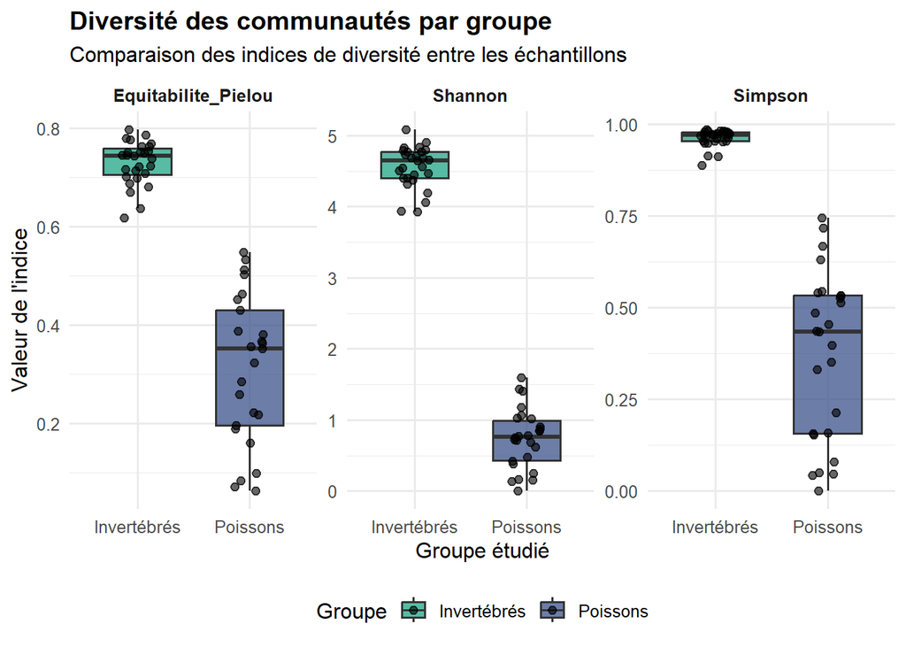

```r
## 29. Visualisation des indices de diversité

indices_long <- indices_diversite %>%
  dplyr::select(
    SampleID,
    Groupe,
    SiteEchantillonnage,
    Shannon,
    Simpson,
    Equitabilite_Pielou
  ) %>%
  tidyr::pivot_longer(
    cols = c(Shannon, Simpson, Equitabilite_Pielou),
    names_to = "Indice",
    values_to = "Valeur"
  )

ggplot2::ggplot(
  indices_long,
  ggplot2::aes(
    x = Groupe,
    y = Valeur,
    fill = Groupe
  )
) +
  ggplot2::geom_boxplot(
    alpha = 0.75,
    outlier.shape = NA,
    width = 0.6
  ) +
  ggplot2::geom_jitter(
    width = 0.15,
    alpha = 0.6,
    size = 2
  ) +
  ggplot2::facet_wrap(
    ~ Indice,
    scales = "free_y"
  ) +
  ggplot2::scale_fill_manual(
    values = c(
      "Invertébrés" = "#20A486",
      "Poissons" = "#3B528B"
    )
  ) +
  ggplot2::labs(
    title = "Diversité des communautés par groupe",
    subtitle = "Comparaison des indices de diversité entre les échantillons",
    x = "Groupe étudié",
    y = "Valeur de l'indice",
    fill = "Groupe"
  ) +
  ggplot2::theme_minimal(base_size = 12) +
  ggplot2::theme(
    plot.title = ggplot2::element_text(face = "bold"),
    strip.text = ggplot2::element_text(face = "bold"),
    legend.position = "bottom"
  )
```

### 5.2.17 Résumé des indices de diversité par site

**Analyse** L’analyse par site met en évidence une hétérogénéité spatiale de la diversité observée.

Chez les invertébrés, le **Fort de Chambly présente la richesse en OTU la plus élevée**, tandis que le **Parc de la Fabrique présente l’indice de Shannon le plus élevé**. Chez les poissons, l’**Amont du barrage présente la richesse la plus élevée,** tandis que **Les écluses présentent l’indice de Shannon le plus élevé.**

Ces résultats suggèrent que les communautés détectées varient selon les sites d’échantillonnage. Cependant, la majorité des sites ne disposant que d’un seul échantillon, ces observations doivent être considérées comme descriptives et exploratoires. Des échantillonnages répétés seraient nécessaires pour confirmer les différences entre sites.

```r
## 30. Résumé des indices de diversité par site

resume_diversite_sites <- indices_diversite %>%
  dplyr::group_by(Groupe, SiteEchantillonnage) %>%
  dplyr::summarise(
    Nombre_echantillons = dplyr::n(),

    Richesse_moyenne = mean(Richesse_OTU),
    Richesse_mediane = median(Richesse_OTU),

    Shannon_moyen = mean(Shannon),
    Shannon_median = median(Shannon),

    Simpson_moyen = mean(Simpson),
    Simpson_median = median(Simpson),

    Equitabilite_moyenne = mean(
      Equitabilite_Pielou,
      na.rm = TRUE
    ),

    .groups = "drop"
  ) %>%
  dplyr::arrange(Groupe, dplyr::desc(Shannon_moyen))

print(
  as.data.frame(resume_diversite_sites),
  row.names = FALSE
)
```

```
##       Groupe             SiteEchantillonnage Nombre_echantillons
##  Invertébrés             Parc.de.la.Fabrique                   1
##  Invertébrés             Berge.des.Baigneurs                   2
##  Invertébrés              Parc.Andre.J..Cote                   1
##  Invertébrés                     Route.verte                   1
##  Invertébrés             Descente.municipale                   1
##  Invertébrés    Rue.du.Bas-du-Plateau-Ouimet                   1
##  Invertébrés             Vieux-Port,.le.pont                   1
##  Invertébrés                  Le.Parc.Martel                   1
##  Invertébrés                     Les.ecluses                   1
##  Invertébrés                 Fort.de.Chambly                   1
##  Invertébrés            Descente.des.ecluses                   1
##  Invertébrés         Vieux-port,.la.descente                   1
##  Invertébrés        Vieux-Port,.la.promenade                   1
##  Invertébrés              Parc.de.Ile.Belair                   1
##  Invertébrés               Parc.Marcel.Seers                   1
##  Invertébrés                Parc.Charbonneau                   1
##  Invertébrés                      Heron.Bleu                   1
##  Invertébrés                 Aval.du.barrage                   1
##  Invertébrés                Amont.du.barrage                   1
##  Invertébrés                Parc.Leon-Gravel                   1
##  Invertébrés                Rue.Saint-Gilles                   1
##  Invertébrés Le.pont.du.Chemin.Saint-Bernard                   1
##  Invertébrés              Parc.Paul-Leveille                   2
##  Invertébrés            Descente.rue.Gilmour                   1
##  Invertébrés                   Montee.Robert                   1
##     Poissons                     Les.ecluses                   1
##     Poissons             Descente.municipale                   1
##     Poissons                     Route.verte                   1
##     Poissons        Vieux-Port,.la.promenade                   1
##     Poissons            Descente.rue.Gilmour                   1
##     Poissons                Amont.du.barrage                   1
##     Poissons             Berge.des.Baigneurs                   2
##     Poissons               Parc.Marcel.Seers                   1
##     Poissons         Vieux-port,.la.descente                   1
##     Poissons                  Le.Parc.Martel                   1
##     Poissons             Vieux-Port,.le.pont                   1
##     Poissons                 Fort.de.Chambly                   1
##     Poissons              Parc.de.Ile.Belair                   1
##     Poissons             Parc.de.la.Fabrique                   1
```

[output cut: 98 more lines]

```
##      0.51309499           0.35208549
##      0.45543340           0.35635691
##      0.43370042           0.28465756
##      0.43622381           0.38729844
##      0.48571351           0.45244630
##      0.33217346           0.25872964
##      0.35158423           0.22269001
##      0.21453857           0.21758927
##      0.15829773           0.16024915
##      0.15315220           0.19631058
##      0.07919525           0.09911233
##      0.05011247           0.08331977
##      0.04753798           0.06281493
##      0.04350958           0.07124692
##      0.00000000                  NaN
```